# Deep Learning Course - Assignment 3

## Home Depot Product Search Relevance

### Submitted by: Itay Bouganim and Ido Rom

### Problem Statement

Shoppers rely on Home Depot’s product authority to find and buy the latest products and to get timely solutions to their home improvement needs. From installing a new ceiling fan to remodeling an entire kitchen, with the click of a mouse or tap of the screen, customers expect the correct results to their queries – quickly. Speed, accuracy and delivering a frictionless customer experience are essential.

### Task Description

Home Depot is asking to help them improve their customers' shopping experience by developing a model that can accurately predict the relevance of search results. Search relevancy is an implicit measure Home Depot uses to gauge how quickly they can get customers to the right products. Currently, human raters evaluate the impact of potential changes to their search algorithms, which is a slow and subjective process. By removing or minimizing human input in search relevance evaluation, Home Depot hopes to increase the number of iterations their team can perform on the current search algorithms.

[Home Depot Product Search Relevance dataset link](https://www.kaggle.com/c/home-depot-product-search-relevance/data)

```python
import numpy as np
import pandas as pd
from time import time
import math
import matplotlib.pyplot as plt
import os

import tensorflow as tf

from os.path import join
```

```python
tf.config.list_physical_devices(device_type=None)
```

```
[PhysicalDevice(name='/physical_device:CPU:0', device_type='CPU'),
 PhysicalDevice(name='/physical_device:XLA_CPU:0', device_type='XLA_CPU'),
 PhysicalDevice(name='/physical_device:GPU:0', device_type='GPU'),
 PhysicalDevice(name='/physical_device:XLA_GPU:0', device_type='XLA_GPU')]
```

```python
def display_image(path, label=None):
    import base64, io
    from IPython.core.display import display, HTML
    from PIL import Image as PILImage

    image = PILImage.open(path)

    output = io.BytesIO()
    image.save(output, format='PNG')
    encoded_string = base64.b64encode(output.getvalue()).decode()

    html = '<img src="data:…"/>'.format(encoded_string) if label is None else '<div style="text-align: center;">{}<img src="data:…" width="200" height="200"/></div>'.format(label, encoded_string)
    display(HTML(html))
```

```python
data_path = './data'
model_save_dir = './saved_models'
model_history_path = './history'
```

```python
# Load files
train = pd.read_csv(join(data_path, 'train.csv'), encoding="ISO-8859-1")
test = pd.read_csv(join(data_path, 'test.csv'), encoding="ISO-8859-1")
test_labels = pd.read_csv(join(data_path, 'solution.csv'), encoding="ISO-8859-1")
product_descriptions = pd.read_csv(join(data_path, 'product_descriptions.csv'))
```

```python
print("Training data columns")
print(train.columns.values)
print("Test data columns")
print(test.columns.values)
print("Product Descriptions data columns")
print(product_descriptions.columns.values)
```

```
Training data columns
['id' 'product_uid' 'product_title' 'search_term' 'relevance']
Test data columns
['id' 'product_uid' 'product_title' 'search_term']
Product Descriptions data columns
['product_uid' 'product_description']
```

```python
train.head()
```

|  | id | product_uid | product_title | search_term | relevance |
| --- | --- | --- | --- | --- | --- |
| 0 | 2 | 100001 | Simpson Strong-Tie 12-Gauge Angle | angle bracket | 3.00 |
| 1 | 3 | 100001 | Simpson Strong-Tie 12-Gauge Angle | l bracket | 2.50 |
| 2 | 9 | 100002 | BEHR Premium Textured DeckOver 1-gal. #SC-141 ... | deck over | 3.00 |
| 3 | 16 | 100005 | Delta Vero 1-Handle Shower Only Faucet Trim Ki... | rain shower head | 2.33 |
| 4 | 17 | 100005 | Delta Vero 1-Handle Shower Only Faucet Trim Ki... | shower only faucet | 2.67 |

```python
test.head()
```

|  | id | product_uid | product_title | search_term |
| --- | --- | --- | --- | --- |
| 0 | 1 | 100001 | Simpson Strong-Tie 12-Gauge Angle | 90 degree bracket |
| 1 | 4 | 100001 | Simpson Strong-Tie 12-Gauge Angle | metal l brackets |
| 2 | 5 | 100001 | Simpson Strong-Tie 12-Gauge Angle | simpson sku able |
| 3 | 6 | 100001 | Simpson Strong-Tie 12-Gauge Angle | simpson strong ties |
| 4 | 7 | 100001 | Simpson Strong-Tie 12-Gauge Angle | simpson strong tie hcc668 |

```python
product_descriptions.head()
```

|  | product_uid | product_description |
| --- | --- | --- |
| 0 | 100001 | Not only do angles make joints stronger, they ... |
| 1 | 100002 | BEHR Premium Textured DECKOVER is an innovativ... |
| 2 | 100003 | Classic architecture meets contemporary design... |
| 3 | 100004 | The Grape Solar 265-Watt Polycrystalline PV So... |
| 4 | 100005 | Update your bathroom with the Delta Vero Singl... |

We can see that the product descriptions, attributes and titles relevance data are seperate.  
We will join the data together.

```python
from functools import reduce

train = pd.merge(train, product_descriptions, on='product_uid', how='left')
train.head()
```

|  | id | product_uid | product_title | search_term | relevance | product_description |
| --- | --- | --- | --- | --- | --- | --- |
| 0 | 2 | 100001 | Simpson Strong-Tie 12-Gauge Angle | angle bracket | 3.00 | Not only do angles make joints stronger, they ... |
| 1 | 3 | 100001 | Simpson Strong-Tie 12-Gauge Angle | l bracket | 2.50 | Not only do angles make joints stronger, they ... |
| 2 | 9 | 100002 | BEHR Premium Textured DeckOver 1-gal. #SC-141 ... | deck over | 3.00 | BEHR Premium Textured DECKOVER is an innovativ... |
| 3 | 16 | 100005 | Delta Vero 1-Handle Shower Only Faucet Trim Ki... | rain shower head | 2.33 | Update your bathroom with the Delta Vero Singl... |
| 4 | 17 | 100005 | Delta Vero 1-Handle Shower Only Faucet Trim Ki... | shower only faucet | 2.67 | Update your bathroom with the Delta Vero Singl... |

```python
test = pd.merge(test, test_labels, on='id', how='left')
test = pd.merge(test, product_descriptions, on='product_uid', how='left')
test.head()
```

|  | id | product_uid | product_title | search_term | relevance | Usage | product_description |
| --- | --- | --- | --- | --- | --- | --- | --- |
| 0 | 1 | 100001 | Simpson Strong-Tie 12-Gauge Angle | 90 degree bracket | -1.00 | Ignored | Not only do angles make joints stronger, they ... |
| 1 | 4 | 100001 | Simpson Strong-Tie 12-Gauge Angle | metal l brackets | 2.33 | Public | Not only do angles make joints stronger, they ... |
| 2 | 5 | 100001 | Simpson Strong-Tie 12-Gauge Angle | simpson sku able | 2.33 | Private | Not only do angles make joints stronger, they ... |
| 3 | 6 | 100001 | Simpson Strong-Tie 12-Gauge Angle | simpson strong ties | 2.67 | Private | Not only do angles make joints stronger, they ... |
| 4 | 7 | 100001 | Simpson Strong-Tie 12-Gauge Angle | simpson strong tie hcc668 | 2.00 | Public | Not only do angles make joints stronger, they ... |

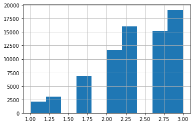

```python
train.relevance.hist()
```

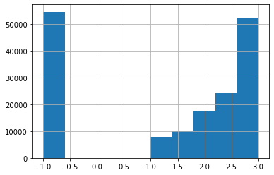

```python
test.relevance.hist()
```

```python
test = test[test.Usage != 'Ignored']
test = test.drop(['Usage'], axis=1)
```

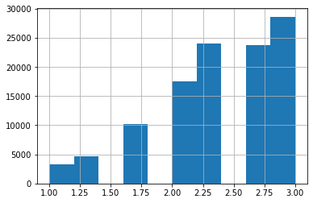

```python
test.relevance.hist()
```

```python
train.relevance.value_counts()
```

```
3.00    19125
2.33    16060
2.67    15202
2.00    11730
1.67     6780
1.33     3006
1.00     2105
2.50       19
2.25       11
2.75       11
1.75        9
1.50        5
1.25        4
Name: relevance, dtype: int64
```

```python
test.relevance.value_counts()
```

```
3.00    28604
2.33    24034
2.67    23642
2.00    17516
1.67    10227
1.33     4676
1.00     3258
2.75       31
2.50       31
2.25       23
1.75       14
1.50        8
1.25        3
Name: relevance, dtype: int64
```

```python
print(f'Train data size: {len(train)}')
print(f'Test data size: {len(test)}')

mean = np.mean(train['relevance'])
print(f'Train mean relevance value: {mean}')

mean = np.mean(test['relevance'])
print(f'Test mean relevance value: {mean}')
```

```
Train data size: 74067
Test data size: 112067
Train mean relevance value: 2.381633791027016
Test mean relevance value: 2.3805248645900994
```

```python
def save_results_dict(d):
    if not os.path.isfile('./model_results.csv'):
        df = pd.DataFrame(columns=['Name', 'MSE', 'MAE', 'RMSE'])
    else:
        df = pd.read_csv('./model_results.csv')
    df = df.append(d, ignore_index=True)
    df.to_csv('./model_results.csv', index=False)
```

## Preface

#### **Task goal:** Finding the relevance value of the connection between a search phrase and a product description in a hardware store website.

In the following sections we are going to train multiple Siamese LSTM based networks with the goal of determining the relevance value for each product according to the search term and product description.  
At first we are going to perform our task at a character based level, meaning that every search term/product description will be tokenized and represented as a sequence of numeric character representations.  
In the second stage we will produce a network on a word level, each search term/product description will be represented as a tokenized sequence of preprocessed numeric words representation.  
We will also using embedding in the second stage in order to produce a vectorized representation for every tokenized word in our corpus.

## 1.a. Character Level LSTM Model Preprocess

#### Character Tokenization

Character Tokenization splits apiece of text into a set of characters.

Character Tokenizers handles OOV words coherently by preserving the information of the word.  
It breaks down the OOV word into characters and represents the word in terms of these characters.  
It also limits the size of the vocabulary.

#### Drawbacks of Character Tokenization

Character tokens solve the OOV problem but the length of the input and output sentences increases rapidly as we are representing a sentence as a sequence of characters.  
As a result, it becomes challenging to learn the relationship between the characters to form meaningful words.

```python
from keras.preprocessing.text import Tokenizer

def create_char_tokenizer(corpus):
    tokenizer = Tokenizer(char_level=True)
    tokenizer.fit_on_texts(corpus)
    return tokenizer
```

```python
def generate_serch_desc_texts(train_df, test_df):
    search_train = train_df['search_term'].to_numpy()
    search_test = test_df['search_term'].to_numpy()
    desc_train = train_df['product_description'].to_numpy()
    desc_test = test_df['product_description'].to_numpy()
    return np.concatenate([search_train, search_test, desc_train, desc_test])

corpus = generate_serch_desc_texts(train, test)
print(corpus)
```

```
['angle bracket' 'l bracket' 'deck over' ...
 'The Tile Kit bathtub wall set has a tile-like appearance that requires no grout.  This is an easy installation for that DYI person, and easy to maintain.  Classic design to add to your existing bathtub.3-piece bathtub wall set fits alcoves 60 in. wide x 30 in. deepTile-like design requires no grou…
 'Your daughter will be a queen ready to cast her enchanted spell this Halloween with the Girls Little Pink Princess Costume. This costume features a deluxe three piece outfit that includes a sleeveless pink gown with a gold belt and a peplum that simulates flower petals. The peplum is covered in a …
 'The 11.5 in. Sharazad Egg Pot is a great addition to any home. The design and unique silver finish look great in a modern setting. The planter is made of stoneware and perfect for outdoor use. Drainage holes prevent over-watering and promote plant health.Stoneware is frost resistantDrainage hole h…
```

```python
%%time
char_tokenizer = create_char_tokenizer(corpus)
```

```
Wall time: 1min 8s
```

```python
print('Character token dictionary after tokenization:')
print(char_tokenizer.word_index)
```

```
Character token dictionary after tokenization:
{' ': 1, 'e': 2, 't': 3, 'a': 4, 'i': 5, 'o': 6, 'n': 7, 'r': 8, 's': 9, 'l': 10, 'd': 11, 'c': 12, 'h': 13, 'u': 14, 'p': 15, 'm': 16, 'f': 17, 'g': 18, 'y': 19, 'w': 20, 'b': 21, '.': 22, 'v': 23, ',': 24, 'k': 25, '-': 26, '1': 27, '0': 28, 'x': 29, '2': 30, '5': 31, '3': 32, '4': 33, 'q': 34, '/…
```

```python
def get_max_min_mean_len(col, df):
    l = np.array([len(c) for c in df[col]])
    return np.max(l), np.min(l), np.mean(l)

max_search_term_train, mn, mean_search_train = get_max_min_mean_len('search_term', train)
print(f'Max train data search term length: {max_search_term_train}')
print(f'Min train data search term length: {mn}')
print(f'Mean train data search term length: {mean_search_train}\n')

max_product_description_train, mn, mean_desc_train = get_max_min_mean_len('product_description', train)
print(f'Max train data product description length: {max_product_description_train}')
print(f'Min train data product description length: {mn}')
print(f'Mean train data product description length: {mean_desc_train}\n')

max_search_term, mn, mean = get_max_min_mean_len('search_term', test)
print(f'Max test data search term length: {max_search_term}')
print(f'Min test data search term length: {mn}')
print(f'Mean test data search term length: {mean}\n')

max_product_description, mn, mean = get_max_min_mean_len('product_description', test)
print(f'Max test data product description length: {max_product_description}')
print(f'Min test data product description length: {mn}')
print(f'Mean test data product description length: {mean}')
```

```
Max train data search term length: 60
Min train data search term length: 2
Mean train data search term length: 19.008816341960657

Max train data product description length: 5516
Min train data product description length: 153
Mean train data product description length: 885.663750388162

Max test data search term length: 60
Min test data search term length: 1
Mean test data search term length: 18.929319068057502

Max test data product description length: 5479
Min test data product description length: 8
Mean test data product description length: 891.1579858477518
```

### We will normalize the relevance values to range between [0, 1] instead of [1, 3]

```python
def normalize_relevance(data, mn=1, mx=3):
    return ((data - mn) / (mx - mn))
```

```python
%%time
from keras.preprocessing.sequence import pad_sequences

data_cols = ['search_term', 'product_description']
cols = ['search_term', 'product_description', 'relevance']
padding_max_lens = {'search_term': max_search_term_train, 'product_description': math.trunc(mean_desc_train)}

def create_padded_sequences(df, tokenizer, padding_max_lens):
    df = df[cols].copy()
    for col in [col for col in cols if col != 'relevance']:
        sequences = tokenizer.texts_to_sequences(df[col])
        padded_sequences = pad_sequences(sequences, maxlen=padding_max_lens[col], padding='post', truncating='post')
        df[col] = padded_sequences.tolist()
    df['relevance'] = df['relevance'].apply(normalize_relevance)
    return df

X_train_df = create_padded_sequences(train, tokenizer=char_tokenizer, padding_max_lens=padding_max_lens)
X_test_df = create_padded_sequences(test, tokenizer=char_tokenizer, padding_max_lens=padding_max_lens)
X_train_df
```

```
Wall time: 1min 36s
```

|  | search_term | product_description | relevance |
| --- | --- | --- | --- |
| 0 | [4, 7, 18, 10, 2, 1, 21, 8, 4, 12, 25, 2, 3, 0... | [7, 6, 3, 1, 6, 7, 10, 19, 1, 11, 6, 1, 4, 7, ... | 1.000 |
| 1 | [10, 1, 21, 8, 4, 12, 25, 2, 3, 0, 0, 0, 0, 0,... | [7, 6, 3, 1, 6, 7, 10, 19, 1, 11, 6, 1, 4, 7, ... | 0.750 |
| 2 | [11, 2, 12, 25, 1, 6, 23, 2, 8, 0, 0, 0, 0, 0,... | [21, 2, 13, 8, 1, 15, 8, 2, 16, 5, 14, 16, 1, ... | 1.000 |
| 3 | [8, 4, 5, 7, 1, 9, 13, 6, 20, 2, 8, 1, 13, 2, ... | [14, 15, 11, 4, 3, 2, 1, 19, 6, 14, 8, 1, 21, ... | 0.665 |
| 4 | [9, 13, 6, 20, 2, 8, 1, 6, 7, 10, 19, 1, 17, 4... | [14, 15, 11, 4, 3, 2, 1, 19, 6, 14, 8, 1, 21, ... | 0.835 |
| ... | ... | ... | ... |
| 74062 | [3, 23, 1, 8, 5, 9, 2, 8, 1, 18, 10, 4, 9, 9, ... | [4, 3, 10, 4, 7, 3, 5, 12, 24, 1, 5, 7, 12, 22... | 0.000 |
| 74063 | [8, 30, 28, 1, 13, 4, 10, 6, 18, 2, 7, 1, 10, ... | [15, 13, 5, 10, 5, 15, 9, 1, 2, 7, 2, 8, 18, 1... | 1.000 |
| 74064 | [9, 12, 13, 10, 4, 18, 2, 1, 10, 6, 12, 25, 1,... | [3, 13, 2, 1, 9, 12, 13, 10, 4, 18, 2, 1, 12, ... | 0.665 |
| 74065 | [37, 2, 7, 1, 18, 4, 8, 11, 2, 7, 1, 1, 11, 2,... | [3, 13, 2, 1, 8, 6, 9, 2, 1, 18, 4, 8, 11, 2, ... | 1.000 |
| 74066 | [17, 5, 7, 2, 1, 9, 13, 2, 2, 8, 1, 12, 14, 8,... | [7, 6, 22, 1, 45, 27, 38, 1, 16, 5, 10, 10, 2,... | 0.665 |

74067 rows × 3 columns

```python
print(f'Train data search sequences length: {max([len(x) for x in X_test_df["search_term"].values])}')
print(f'Train data description sequences length: {max([len(x) for x in X_test_df["product_description"].values])}')
```

```
Train data search sequences length: 60
Train data description sequences length: 885
```

```python
from keras.preprocessing.sequence import pad_sequences
from sklearn.model_selection import train_test_split

def extract_np_arrays(col, extract):
    return np.array([np.array(x) for x in col.to_numpy()]) if extract else col.to_numpy()

def create_X_y_splits(X_train_df, X_test_df, extract=True):
    X_train_df, X_valid_df, y_train, y_valid = train_test_split(X_train_df[data_cols], X_train_df.relevance, test_size=0.2)
    X_test_df, y_test = X_test_df[data_cols], X_test_df.relevance
    X_train = {'search': extract_np_arrays(X_train_df['search_term'], extract), 'desc': extract_np_arrays(X_train_df['product_description'], extract)}
    X_valid = {'search': extract_np_arrays(X_valid_df['search_term'], extract), 'desc': extract_np_arrays(X_valid_df['product_description'], extract)}
    X_test = {'search': extract_np_arrays(X_test_df['search_term'], extract), 'desc': extract_np_arrays(X_test_df['product_description'], extract)}
    return X_train, y_train.to_numpy(), X_valid, y_valid.to_numpy(), X_test, y_test.to_numpy()
```

```python
X_train, y_train, X_valid, y_valid, X_test, y_test = create_X_y_splits(X_train_df, X_test_df)

print("X, Y shapes:")
print(f'X train (search term: {X_train["search"].shape}, product description: {X_train["desc"].shape}), Y train: {y_train.shape}')
print(f'X valid (search term: {X_valid["search"].shape}, product description: {X_valid["desc"].shape}), Y valid: {y_valid.shape}')
print(f'X test (search term: {X_test["search"].shape}, product description: {X_test["desc"].shape}), Y test: {y_test.shape}')
```

```
X, Y shapes:
X train (search term: (59253, 60), product description: (59253, 885)), Y train: (59253,)
X valid (search term: (14814, 60), product description: (14814, 885)), Y valid: (14814,)
X test (search term: (112067, 60), product description: (112067, 885)), Y test: (112067,)
```

## 1.b. Character Level LSTM Model

```python
from tensorflow.keras.callbacks import EarlyStopping, ModelCheckpoint, ReduceLROnPlateau

def get_callbacks(saved_model_name):
    early_stopping_callback = EarlyStopping(monitor="val_loss", patience=5, verbose=2)
    rlop_callback = ReduceLROnPlateau(patience=3)
    checkpoint_callback = ModelCheckpoint(join(model_save_dir, f'model_{saved_model_name}.h5'),
                                                monitor='val_loss', verbose=1,
                                                save_best_only=True, mode='min')
    return [early_stopping_callback, checkpoint_callback, rlop_callback]
```

```python
def save_history(history, model_name):
    np.save(join(model_history_path, f'{model_name}_history.npy'), history.history)

def load_history(model_name):
    return np.load(join(model_history_path, f'{model_name}_history.npy'), allow_pickle='TRUE').item()
```

```python
def plot_history(history, plot_title, metrics):
    fig, axes = plt.subplots(nrows=1, ncols=len(metrics), figsize=(len(metrics) * 6, 4))

    # Plot training & validation accuracy values
    for i, metric in enumerate(metrics):
        axes[i].plot(history[metric])
        axes[i].plot(history[f'val_{metric}'])
        axes[i].legend(['Train', 'Validation'], loc='upper right')
        axes[i].set_title(f'Model {metric.replace("_metric", "").upper()} Metric')
        axes[i].set_ylabel(metric.upper())
        axes[i].set_xlabel('Epoch')
        axes[i].grid()

    fig.suptitle(plot_title + " Metrics History", y=1.05)
    plt.tight_layout()
    plt.show()
```

```python
def plot_model_history(model_name, metrics=['mse', 'mae', 'root_mean_squared_error']):
    history = load_history(model_name)
    plot_history(history, model_name.replace('_', ' ').title(), metrics)
```

### We are going to use RMSE loss function

```python
import keras.backend as K

def root_mean_squared_error(y_true, y_pred):
    return K.sqrt(K.mean(K.square(y_pred - y_true)))
```

### To determine each model output vector semantic meaning simillarity we will put them through the defined similarity function (below)

```python
display_image('exp_man.png')
```

[output not shown]

```python
def exponent_neg_manhattan_distance(left, right):
    ''' Helper function for the similarity estimate of the LSTMs outputs'''
    return K.exp(-K.sum(K.abs(left - right), axis=1, keepdims=True))
```

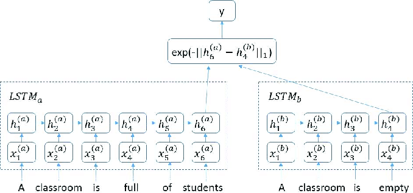

```python
display_image('malstm2.png')
```

```python
## print(pow(2, math.floor(math.log(855)/math.log(2))))
```

[output not shown]

#### First we will try a network without joined weights

We will train a network with same models for search phrase input and product description input (different models) and combine them by using the exponent manhattan distance function to determine simillarities.

```python
from keras.models import Model
from keras.layers import Input, LSTM, Lambda, Dense, Dropout
from keras.optimizers import Adadelta, Adam
from tensorflow.keras.utils import plot_model

def siamese_model(input_shape, name):
    inp = Input(shape=input_shape)
    x = LSTM(128, dropout=0.2, return_sequences=True)(inp)
    x = Dropout(0.2)(x)
    x = LSTM(128, dropout=0.2,)(x)
    return Model(inputs=inp, outputs=x, name=name)

ex_siamese_model = siamese_model((X_train['search'].shape[1], 1), 'Example Siamese Model')
ex_siamese_model.summary()

def create_char_siamese_model():
    search_inp = Input(shape=(X_train['search'].shape[1], 1))
    desc_inp = Input(shape=(X_train['desc'].shape[1], 1))
    search_model = siamese_model(input_shape=(X_train['search'].shape[1], 1), name='search_siamese')(search_inp)
    desc_model = siamese_model(input_shape=(X_train['desc'].shape[1], 1), name='description_siamese')(desc_inp)
    x = Lambda(function=lambda x: exponent_neg_manhattan_distance(x[0], x[1]))([search_model, desc_model])
    y = Dense(1, activation='sigmoid')(x)

    model = Model([search_inp, desc_inp], y)
    model.compile(loss=root_mean_squared_error, optimizer='adam', metrics=['mse', 'mae', root_mean_squared_error])
    return model

siamese_char_seq_model = create_char_siamese_model()
siamese_char_seq_model.summary()
```

```
Model: "Example Siamese Model"
_________________________________________________________________
Layer (type)                 Output Shape              Param #
=================================================================
input_1 (InputLayer)         [(None, 60, 1)]           0
_________________________________________________________________
lstm (LSTM)                  (None, 60, 128)           66560
_________________________________________________________________
dropout (Dropout)            (None, 60, 128)           0
_________________________________________________________________
lstm_1 (LSTM)                (None, 128)               131584
=================================================================
Total params: 198,144
Trainable params: 198,144
Non-trainable params: 0
_________________________________________________________________
Model: "functional_1"
__________________________________________________________________________________________________
Layer (type)                    Output Shape         Param #     Connected to
==================================================================================================
input_2 (InputLayer)            [(None, 60, 1)]      0
__________________________________________________________________________________________________
input_3 (InputLayer)            [(None, 885, 1)]     0
__________________________________________________________________________________________________
search_siamese (Functional)     (None, 128)          198144      input_2[0][0]
__________________________________________________________________________________________________
description_siamese (Functional (None, 128)          198144      input_3[0][0]
__________________________________________________________________________________________________
lambda (Lambda)                 (None, 1)            0           search_siamese[0][0]
                                                                 description_siamese[0][0]
__________________________________________________________________________________________________
dense (Dense)                   (None, 1)            2           lambda[0][0]
==================================================================================================
Total params: 396,290
Trainable params: 396,290
Non-trainable params: 0
__________________________________________________________________________________________________
```

```python
history = siamese_char_seq_model.fit((X_train['search'], X_train['desc']), y_train, batch_size=256, epochs=10,
                            validation_data=((X_valid['search'], X_valid['desc']), y_valid), callbacks=get_callbacks('char_seq_siamese'))
save_history(history, 'char_seq_siamese')
```

```
Epoch 00001: val_loss improved from inf to 0.29888, saving model to ./saved_models\model_char_seq_siamese.h5
Epoch 00002: val_loss improved from 0.29888 to 0.28076, saving model to ./saved_models\model_char_seq_siamese.h5
Epoch 00003: val_loss improved from 0.28076 to 0.27139, saving model to ./saved_models\model_char_seq_siamese.h5
Epoch 00004: val_loss improved from 0.27139 to 0.26715, saving model to ./saved_models\model_char_seq_siamese.h5
Epoch 00005: val_loss improved from 0.26715 to 0.26548, saving model to ./saved_models\model_char_seq_siamese.h5
Epoch 00006: val_loss improved from 0.26548 to 0.26486, saving model to ./saved_models\model_char_seq_siamese.h5
Epoch 00007: val_loss improved from 0.26486 to 0.26468, saving model to ./saved_models\model_char_seq_siamese.h5
Epoch 00008: val_loss improved from 0.26468 to 0.26462, saving model to ./saved_models\model_char_seq_siamese.h5
Epoch 00009: val_loss improved from 0.26462 to 0.26460, saving model to ./saved_models\model_char_seq_siamese.h5
Epoch 00010: val_loss improved from 0.26460 to 0.26459, saving model to ./saved_models\model_char_seq_siamese.h5
```

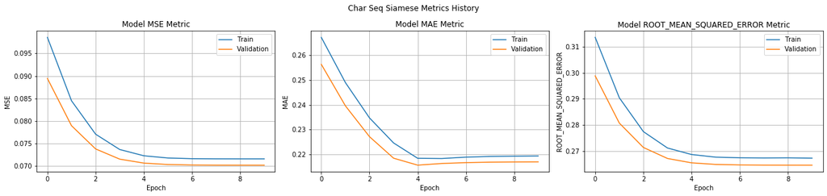

```python
plot_model_history(model_name='char_seq_siamese')
```

```python
from keras.models import load_model
from sklearn.metrics import mean_squared_error, mean_absolute_error

def calculate_model_results(create_model_func, saved_model_name, X_test, X_train, X_valid, y_test, y_train, y_valid):
    model = create_model_func()
    model.load_weights(join(model_save_dir, f'model_{saved_model_name}.h5'))
    model_name = saved_model_name.replace('_', ' ').title()

    print('Test data results:')
    y_pred = model.predict((X_test['search'], X_test['desc']), verbose=1)
    print(f'{model_name} RMSE: {np.sqrt(mean_squared_error(y_test, y_pred))}')
    print(f'{model_name} MSE: {mean_squared_error(y_test, y_pred)}')
    print(f'{model_name} MAE: {mean_absolute_error(y_test, y_pred)}')
    save_results_dict({'Name': saved_model_name, 'MSE': mean_squared_error(y_test, y_pred), 'MAE': mean_absolute_error(y_test, y_pred), 'RMSE':np.sqrt(mean_squared_error(y_test, y_pred))})

    print('\nValidation data results:')
    y_pred = model.predict((X_valid['search'], X_valid['desc']), verbose=1)
    print(f'{model_name} RMSE: {np.sqrt(mean_squared_error(y_valid, y_pred))}')
    print(f'{model_name} MSE: {mean_squared_error(y_valid, y_pred)}')
    print(f'{model_name} MAE: {mean_absolute_error(y_valid, y_pred)}')

    print('\nTrain data results:')
    y_pred = model.predict((X_train['search'], X_train['desc']), verbose=1)
    print(f'{model_name} RMSE: {np.sqrt(mean_squared_error(y_train, y_pred))}')
    print(f'{model_name} MSE: {mean_squared_error(y_train, y_pred)}')
    print(f'{model_name} MAE: {mean_absolute_error(y_train, y_pred)}')
```

```python
calculate_model_results(create_char_siamese_model, 'char_seq_siamese', X_test, X_train, X_valid, y_test, y_train, y_valid)
```

```
Test data results:
Char Seq Siamese RMSE: 0.26763587052709054
Char Seq Siamese MSE: 0.07162895919279358
Char Seq Siamese MAE: 0.21933228496245008

Validation data results:
Char Seq Siamese RMSE: 0.26489372462495714
Char Seq Siamese MSE: 0.07016868534568263
Char Seq Siamese MAE: 0.21699708677905766

Train data results:
Char Seq Siamese RMSE: 0.26751203080482217
Char Seq Siamese MSE: 0.07156268662532013
Char Seq Siamese MAE: 0.21939520269499052
```

### We will now use siamese model with common weights (train a single layer for both inputs to train on)

Now we will train a true siamese network (train on the same model with same weights for both input vectors)

```python
padding_max_lens = {'search_term': math.trunc(mean_desc_train), 'product_description': math.trunc(mean_desc_train)}

X_train_df = create_padded_sequences(train, tokenizer=char_tokenizer, padding_max_lens=padding_max_lens)
X_test_df = create_padded_sequences(test, tokenizer=char_tokenizer, padding_max_lens=padding_max_lens)
X_train_df
```

|  | search_term | product_description | relevance |
| --- | --- | --- | --- |
| 0 | [4, 7, 18, 10, 2, 1, 21, 8, 4, 12, 25, 2, 3, 0... | [7, 6, 3, 1, 6, 7, 10, 19, 1, 11, 6, 1, 4, 7, ... | 1.000 |
| 1 | [10, 1, 21, 8, 4, 12, 25, 2, 3, 0, 0, 0, 0, 0,... | [7, 6, 3, 1, 6, 7, 10, 19, 1, 11, 6, 1, 4, 7, ... | 0.750 |
| 2 | [11, 2, 12, 25, 1, 6, 23, 2, 8, 0, 0, 0, 0, 0,... | [21, 2, 13, 8, 1, 15, 8, 2, 16, 5, 14, 16, 1, ... | 1.000 |
| 3 | [8, 4, 5, 7, 1, 9, 13, 6, 20, 2, 8, 1, 13, 2, ... | [14, 15, 11, 4, 3, 2, 1, 19, 6, 14, 8, 1, 21, ... | 0.665 |
| 4 | [9, 13, 6, 20, 2, 8, 1, 6, 7, 10, 19, 1, 17, 4... | [14, 15, 11, 4, 3, 2, 1, 19, 6, 14, 8, 1, 21, ... | 0.835 |
| ... | ... | ... | ... |
| 74062 | [3, 23, 1, 8, 5, 9, 2, 8, 1, 18, 10, 4, 9, 9, ... | [4, 3, 10, 4, 7, 3, 5, 12, 24, 1, 5, 7, 12, 22... | 0.000 |
| 74063 | [8, 30, 28, 1, 13, 4, 10, 6, 18, 2, 7, 1, 10, ... | [15, 13, 5, 10, 5, 15, 9, 1, 2, 7, 2, 8, 18, 1... | 1.000 |
| 74064 | [9, 12, 13, 10, 4, 18, 2, 1, 10, 6, 12, 25, 1,... | [3, 13, 2, 1, 9, 12, 13, 10, 4, 18, 2, 1, 12, ... | 0.665 |
| 74065 | [37, 2, 7, 1, 18, 4, 8, 11, 2, 7, 1, 1, 11, 2,... | [3, 13, 2, 1, 8, 6, 9, 2, 1, 18, 4, 8, 11, 2, ... | 1.000 |
| 74066 | [17, 5, 7, 2, 1, 9, 13, 2, 2, 8, 1, 12, 14, 8,... | [7, 6, 22, 1, 45, 27, 38, 1, 16, 5, 10, 10, 2,... | 0.665 |

74067 rows × 3 columns

We will use the mean description length as the char sequence size

```python
X_train, y_train, X_valid, y_valid, X_test, y_test = create_X_y_splits(X_train_df, X_test_df)

print("X, Y shapes:")
print(f'X train (search term: {X_train["search"].shape}, product description: {X_train["desc"].shape}), Y train: {y_train.shape}')
print(f'X valid (search term: {X_valid["search"].shape}, product description: {X_valid["desc"].shape}), Y valid: {y_valid.shape}')
print(f'X test (search term: {X_test["search"].shape}, product description: {X_test["desc"].shape}), Y test: {y_test.shape}')
```

```
X, Y shapes:
X train (search term: (59253, 885), product description: (59253, 885)), Y train: (59253,)
X valid (search term: (14814, 885), product description: (14814, 885)), Y valid: (14814,)
X test (search term: (112067, 885), product description: (112067, 885)), Y test: (112067,)
```

```python
def create_char_siamese_joined_model():
    search_inp = Input(shape=(X_train['search'].shape[1], 1))
    desc_inp = Input(shape=(X_train['desc'].shape[1], 1))
    lstm1 = LSTM(128, dropout=0.2, return_sequences=True)
    x1 = lstm1(search_inp)
    x2 = lstm1(desc_inp)
    lstm2 = LSTM(128, dropout=0.2)
    x1 = lstm2(x1)
    x2 = lstm2(x2)
    x = Lambda(function=lambda x: exponent_neg_manhattan_distance(x[0], x[1]))([x1, x2])
    y = Dense(1, activation='sigmoid')(x)

    model = Model([search_inp, desc_inp], y)
    model.compile(loss=root_mean_squared_error, optimizer='adam', metrics=['mse', 'mae', root_mean_squared_error])
    return model

siamese_char_seq_joined_model = create_char_siamese_joined_model()
siamese_char_seq_joined_model.summary()
```

```
Model: "functional_5"
__________________________________________________________________________________________________
Layer (type)                    Output Shape         Param #     Connected to
==================================================================================================
input_8 (InputLayer)            [(None, 885, 1)]     0
__________________________________________________________________________________________________
input_9 (InputLayer)            [(None, 885, 1)]     0
__________________________________________________________________________________________________
lstm_8 (LSTM)                   (None, 885, 128)     66560       input_8[0][0]
                                                                 input_9[0][0]
__________________________________________________________________________________________________
lstm_9 (LSTM)                   (None, 128)          131584      lstm_8[0][0]
                                                                 lstm_8[1][0]
__________________________________________________________________________________________________
lambda_2 (Lambda)               (None, 1)            0           lstm_9[0][0]
                                                                 lstm_9[1][0]
__________________________________________________________________________________________________
dense_2 (Dense)                 (None, 1)            2           lambda_2[0][0]
==================================================================================================
Total params: 198,146
Trainable params: 198,146
Non-trainable params: 0
__________________________________________________________________________________________________
```

```python
history = siamese_char_seq_joined_model.fit((X_train['search'], X_train['desc']), y_train, batch_size=64, epochs=10,
                            validation_data=((X_valid['search'], X_valid['desc']), y_valid), callbacks=get_callbacks('char_seq_joined_siamese'))
save_history(history, 'char_seq_joined_siamese')
```

```
Epoch 00001: val_loss improved from inf to 0.29446, saving model to ./saved_models\model_char_seq_joined_siamese.h5
Epoch 00002: val_loss improved from 0.29446 to 0.28956, saving model to ./saved_models\model_char_seq_joined_siamese.h5
Epoch 00003: val_loss improved from 0.28956 to 0.28782, saving model to ./saved_models\model_char_seq_joined_siamese.h5
Epoch 00004: val_loss improved from 0.28782 to 0.28595, saving model to ./saved_models\model_char_seq_joined_siamese.h5
Epoch 00005: val_loss improved from 0.28595 to 0.28272, saving model to ./saved_models\model_char_seq_joined_siamese.h5
Epoch 00006: val_loss improved from 0.28272 to 0.28180, saving model to ./saved_models\model_char_seq_joined_siamese.h5
Epoch 00007: val_loss improved from 0.28180 to 0.27782, saving model to ./saved_models\model_char_seq_joined_siamese.h5
Epoch 00008: val_loss improved from 0.27782 to 0.27674, saving model to ./saved_models\model_char_seq_joined_siamese.h5
Epoch 00009: val_loss improved from 0.27674 to 0.27426, saving model to ./saved_models\model_char_seq_joined_siamese.h5
Epoch 00010: val_loss improved from 0.27426 to 0.27296, saving model to ./saved_models\model_char_seq_joined_siamese.h5
```

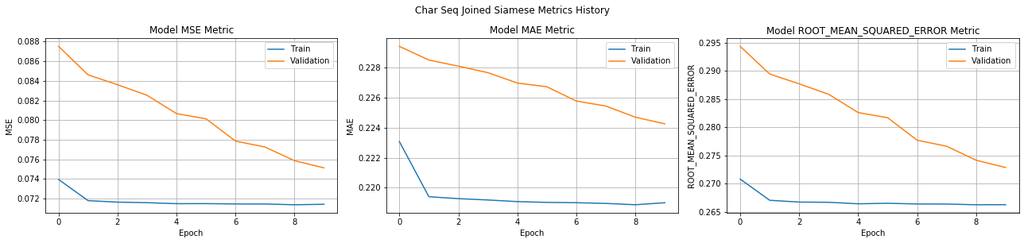

```python
plot_model_history(model_name='char_seq_joined_siamese')
```

```python
calculate_model_results(create_char_siamese_joined_model, 'char_seq_joined_siamese', X_test, X_train, X_valid, y_test, y_train, y_valid)
```

```
Test data results:
Char Seq Joined Siamese RMSE: 0.27407735574900677
Char Seq Joined Siamese MSE: 0.07511839693436762
Char Seq Joined Siamese MAE: 0.22332423770733104

Validation data results:
Char Seq Joined Siamese RMSE: 0.27410554637302154
Char Seq Joined Siamese MSE: 0.07513385055245266
Char Seq Joined Siamese MAE: 0.22425943334543286

Train data results:
Char Seq Joined Siamese RMSE: 0.27318294490269157
Char Seq Joined Siamese MSE: 0.07462892138570701
Char Seq Joined Siamese MAE: 0.2230227561248734
```

## 1.c. Baseline

### Naive mean calculation baseline

We will start with most Naive baseline by calculating the mean relevance for the training and testing data and caculate the MSE, MAE and RMSE metrics for it.

```python
train_mean = np.mean(train['relevance'])
test_mean = np.mean(test['relevance'])

print(f'Train mean relevance: {train_mean}')
print(f'Test mean relevance: {test_mean}')
```

```
Train mean relevance: 2.381633791027016
Test mean relevance: 2.3805248645900994
```

```python
model_name = 'naive_baseline'

print('Test data results:')
y_true = test['relevance'].values
mean_pred = np.full(shape=test.shape[0], fill_value=test_mean)
print(f'{model_name} RMSE: {np.sqrt(mean_squared_error(y_true, mean_pred))}')
print(f'{model_name} MSE: {mean_squared_error(y_true, mean_pred)}')
print(f'{model_name} MAE: {mean_absolute_error(y_true, mean_pred)}')
save_results_dict({'Name': model_name, 'MSE': mean_squared_error(y_true, mean_pred), 'MAE': mean_absolute_error(y_true, mean_pred), 'RMSE':np.sqrt(mean_squared_error(y_true, mean_pred))})

print('\nTrain data results:')
y_true = train['relevance'].values
mean_pred = np.full(shape=train.shape[0], fill_value=train_mean)
print(f'{model_name} RMSE: {np.sqrt(mean_squared_error(y_true, mean_pred))}')
print(f'{model_name} MSE: {mean_squared_error(y_true, mean_pred)}')
print(f'{model_name} MAE: {mean_absolute_error(y_true, mean_pred)}')
```

```
Test data results:
naive_baseline RMSE: 0.5352715864190928
naive_baseline MSE: 0.2865156712276123
naive_baseline MAE: 0.4386375183244027

Train data results:
naive_baseline RMSE: 0.5339803436691322
naive_baseline MSE: 0.2851350074250045
naive_baseline MAE: 0.43788185944303953
```

### Baseline Count Vectorizer model

As we have seen, In order to use textual data for predictive modeling, the text must be parsed to remove certain words – this process is called tokenization.  
These words need to then be encoded as integers, or floating-point values, for use as inputs in machine learning algorithms.  
This process is called feature extraction (or vectorization).

Scikit-learn’s **CountVectorizer** is used to convert a collection of text documents to a vector of term/token counts.  
It also enables the pre-processing of text data prior to generating the vector representation.  
This functionality makes it a highly flexible feature representation module for text.

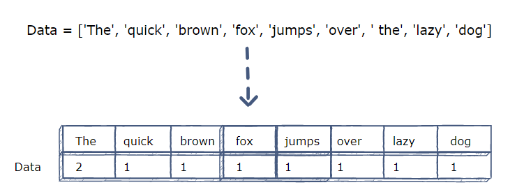

```python
display_image('count_vec.png')
```

```python
%%time
from sklearn.feature_extraction.text import CountVectorizer

def create_fit_count_vectorizer(corpus):
    count_vec = CountVectorizer(analyzer='char')
    count_vec.fit_transform(corpus)
    return count_vec

count_vec = create_fit_count_vectorizer(corpus)
```

```
Wall time: 1min 4s
```

```python
def fit_to_count_vec(df, count_vec=count_vec):
    return np.squeeze(count_vec.transform(df).toarray())

def create_count_vectorizer_X_y(train, test):
    X_train_df, X_valid_df, y_train, y_valid = train_test_split(train[data_cols], train.relevance.apply(normalize_relevance), test_size=0.2)
    X_test_df, y_test = test[data_cols], test.relevance.apply(normalize_relevance)
    X_train = {'search': fit_to_count_vec(X_train_df['search_term']), 'desc': fit_to_count_vec(X_train_df['product_description'])}
    X_valid = {'search': fit_to_count_vec(X_valid_df['search_term']), 'desc': fit_to_count_vec(X_valid_df['product_description'])}
    X_test = {'search': fit_to_count_vec(X_test_df['search_term']), 'desc': fit_to_count_vec(X_test_df['product_description'])}

    return X_train, y_train, X_valid, y_valid, X_test, y_test

X_train_cv, y_train_cv, X_valid_cv, y_valid_cv, X_test_cv, y_test_cv = create_count_vectorizer_X_y(train, test)

print(f"Benchmark train data shape: (search: {X_train_cv['search'].shape}, description: {X_train_cv['desc'].shape}), Y: {y_train_cv.shape}")
print(f"Benchmark valid data shape: (search: {X_test_cv['search'].shape}, description: {X_test_cv['desc'].shape}), Y: {y_test_cv.shape}")
print(f"Benchmark test data shape: (search: {X_valid_cv['search'].shape}, description: {X_valid_cv['desc'].shape}), Y: {y_valid_cv.shape}")
```

```
Benchmark train data shape: (search: (59253, 68), description: (59253, 68)), Y: (59253,)
Benchmark valid data shape: (search: (112067, 68), description: (112067, 68)), Y: (112067,)
Benchmark test data shape: (search: (14814, 68), description: (14814, 68)), Y: (14814,)
```

```python
y_train_cv
```

```
16778    0.665
37795    0.335
69352    0.835
25642    0.335
38757    1.000
         ...
26059    1.000
42922    0.835
10586    0.835
46442    1.000
46589    0.500
Name: relevance, Length: 59253, dtype: float64
```

```python
def benchmark_siamese_model(input_shape, name):
    inp = Input(shape=input_shape)
    x = Dense(512, activation='relu')(inp)
    x = Dense(256, activation='relu')(x)
    return Model(inputs=inp, outputs=x, name=name)

benchmark_ex_siamese_model = benchmark_siamese_model(X_train_cv['search'].shape[1], 'Example Benchamrk Siamese Model')
benchmark_ex_siamese_model.summary()

def create_benchmark_char_siamese_model(count_vec_size):
    search_inp = Input(shape=count_vec_size)
    desc_inp = Input(shape=count_vec_size)
    search_model = benchmark_siamese_model(input_shape=count_vec_size, name='search_siamese')(search_inp)
    desc_model = benchmark_siamese_model(input_shape=count_vec_size, name='description_siamese')(desc_inp)
    x = Lambda(function=lambda x: exponent_neg_manhattan_distance(x[0], x[1]))([search_model, desc_model])
    y = Dense(1, activation='sigmoid')(x)

    model = Model([search_inp, desc_inp], y)
    model.compile(loss=root_mean_squared_error, optimizer='adam', metrics=['mse', 'mae', root_mean_squared_error])
    return model

benchmark_siamese_char_seq_model = create_benchmark_char_siamese_model(count_vec_size=len(count_vec.vocabulary_.keys()))
benchmark_siamese_char_seq_model.summary()
```

```
Model: "Example Benchamrk Siamese Model"
_________________________________________________________________
Layer (type)                 Output Shape              Param #
=================================================================
input_10 (InputLayer)        [(None, 68)]              0
_________________________________________________________________
dense_2 (Dense)              (None, 512)               35328
_________________________________________________________________
dense_3 (Dense)              (None, 256)               131328
=================================================================
Total params: 166,656
Trainable params: 166,656
Non-trainable params: 0
_________________________________________________________________
Model: "functional_5"
__________________________________________________________________________________________________
Layer (type)                    Output Shape         Param #     Connected to
==================================================================================================
input_11 (InputLayer)           [(None, 68)]         0
__________________________________________________________________________________________________
input_12 (InputLayer)           [(None, 68)]         0
__________________________________________________________________________________________________
search_siamese (Functional)     (None, 256)          166656      input_11[0][0]
__________________________________________________________________________________________________
description_siamese (Functional (None, 256)          166656      input_12[0][0]
__________________________________________________________________________________________________
lambda_2 (Lambda)               (None, 1)            0           search_siamese[0][0]
                                                                 description_siamese[0][0]
__________________________________________________________________________________________________
dense_8 (Dense)                 (None, 1)            2           lambda_2[0][0]
==================================================================================================
Total params: 333,314
Trainable params: 333,314
Non-trainable params: 0
__________________________________________________________________________________________________
```

```python
history = benchmark_siamese_char_seq_model.fit((X_train_cv['search'], X_train_cv['desc']), y_train_cv, batch_size=256, epochs=10,
                            validation_data=((X_valid_cv['search'], X_valid_cv['desc']), y_valid_cv), callbacks=get_callbacks('benchmark_char_seq_siamese'))
save_history(history, 'benchmark_char_seq_siamese')
```

```
Epoch 00001: val_loss improved from inf to 0.29960, saving model to ./saved_models\model_benchmark_char_seq_siamese.h5
Epoch 00002: val_loss improved from 0.29960 to 0.28263, saving model to ./saved_models\model_benchmark_char_seq_siamese.h5
Epoch 00003: val_loss improved from 0.28263 to 0.27400, saving model to ./saved_models\model_benchmark_char_seq_siamese.h5
Epoch 00004: val_loss improved from 0.27400 to 0.27035, saving model to ./saved_models\model_benchmark_char_seq_siamese.h5
Epoch 00005: val_loss improved from 0.27035 to 0.26903, saving model to ./saved_models\model_benchmark_char_seq_siamese.h5
Epoch 00006: val_loss improved from 0.26903 to 0.26867, saving model to ./saved_models\model_benchmark_char_seq_siamese.h5
Epoch 00007: val_loss improved from 0.26867 to 0.26860, saving model to ./saved_models\model_benchmark_char_seq_siamese.h5
Epoch 00008: val_loss did not improve from 0.26860
Epoch 00009: val_loss did not improve from 0.26860
Epoch 00010: val_loss did not improve from 0.26860
Epoch 00010: early stopping
```

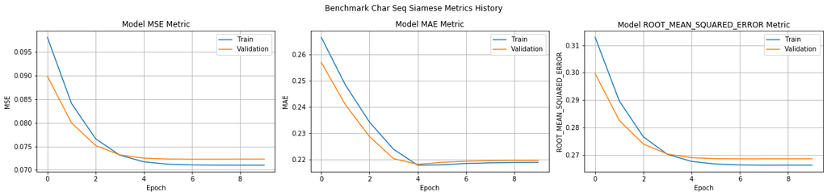

```python
plot_model_history(model_name='benchmark_char_seq_siamese')
```

```python
calculate_model_results(lambda: create_benchmark_char_siamese_model(count_vec_size=len(count_vec.vocabulary_.keys())), 'benchmark_char_seq_siamese', X_test_cv, X_train_cv, X_valid_cv, y_test_cv, y_train_cv, y_valid_cv)
```

```
Test data results:
Benchmark Char Seq Siamese RMSE: 0.26765307157572427
Benchmark Char Seq Siamese MSE: 0.07163816672391977
Benchmark Char Seq Siamese MAE: 0.2191165586465967

Validation data results:
Benchmark Char Seq Siamese RMSE: 0.268867743504799
Benchmark Char Seq Siamese MSE: 0.07228986349736238
Benchmark Char Seq Siamese MAE: 0.21925096545606326

Train data results:
Benchmark Char Seq Siamese RMSE: 0.2665490056182621
Benchmark Char Seq Siamese MSE: 0.07104837239608433
Benchmark Char Seq Siamese MAE: 0.2185385792614681
```

#### We can see that out baseline benchmark model produced simillar results to the Character Level LSTM model

## 1.d. Use LSTM model as Feature Extractor for classical ML algorithms

```python
def fe_ml_model_scores(model_name, ml_model, fe_model):
    preds = fe_model.predict((X_test['search'], X_test['desc']), verbose=1)
    print('Test data results:')
    y_pred = ml_model.predict(preds)
    print(f'{model_name} RMSE: {np.sqrt(mean_squared_error(y_test, y_pred))}')
    print(f'{model_name} MSE: {mean_squared_error(y_test, y_pred)}')
    print(f'{model_name} MAE: {mean_absolute_error(y_test, y_pred)}')
    save_results_dict({'Name': model_name, 'MSE': mean_squared_error(y_test, y_pred), 'MAE': mean_absolute_error(y_test, y_pred), 'RMSE':np.sqrt(mean_squared_error(y_test, y_pred))})

    preds = fe_model.predict((X_valid['search'], X_valid['desc']), verbose=1)
    print('\nValidation data results:')
    y_pred = ml_model.predict(preds)
    print(f'{model_name} RMSE: {np.sqrt(mean_squared_error(y_valid, y_pred))}')
    print(f'{model_name} MSE: {mean_squared_error(y_valid, y_pred)}')
    print(f'{model_name} MAE: {mean_absolute_error(y_valid, y_pred)}')

    preds = fe_model.predict((X_train['search'], X_train['desc']), verbose=1)
    print('\nTrain data results:')
    y_pred = ml_model.predict(preds)
    print(f'{model_name} RMSE: {np.sqrt(mean_squared_error(y_train, y_pred))}')
    print(f'{model_name} MSE: {mean_squared_error(y_train, y_pred)}')
    print(f'{model_name} MAE: {mean_absolute_error(y_train, y_pred)}')
```

```python
siamese_char_seq_model_fe = create_char_siamese_model()
siamese_char_seq_model_fe.load_weights(join(model_save_dir, f'model_char_seq_siamese.h5'))
siamese_char_seq_model_fe = Model(siamese_char_seq_model_fe.inputs, siamese_char_seq_model_fe.layers[-2].output)
siamese_char_seq_model_fe.summary()
```

```
Model: "functional_19"
__________________________________________________________________________________________________
Layer (type)                    Output Shape         Param #     Connected to
==================================================================================================
input_31 (InputLayer)           [(None, 60, 1)]      0
__________________________________________________________________________________________________
input_32 (InputLayer)           [(None, 885, 1)]     0
__________________________________________________________________________________________________
search_siamese (Functional)     (None, 128)          198144      input_31[0][0]
__________________________________________________________________________________________________
description_siamese (Functional (None, 128)          198144      input_32[0][0]
__________________________________________________________________________________________________
lambda_7 (Lambda)               (None, 1)            0           search_siamese[0][0]
                                                                 description_siamese[0][0]
==================================================================================================
Total params: 396,288
Trainable params: 396,288
Non-trainable params: 0
__________________________________________________________________________________________________
```

```python
preds = siamese_char_seq_model_fe.predict((X_train['search'], X_train['desc']), verbose=1)
```

```python
from xgboost import XGBRegressor

xgboost_model = XGBRegressor(n_estimators=100, verbosity=1, eval_metric='rmse', objective='reg:squarederror')
xgboost_model.fit(preds, y_train)
```

```
XGBRegressor(base_score=0.5, booster='gbtree', colsample_bylevel=1,
             colsample_bynode=1, colsample_bytree=1, eval_metric='rmse',
             gamma=0, gpu_id=-1, importance_type='gain',
             interaction_constraints='', learning_rate=0.300000012,
             max_delta_step=0, max_depth=6, min_child_weight=1, missing=nan,
             monotone_constraints='()', n_estimators=100, n_jobs=8,
             num_parallel_tree=1, random_state=0, reg_alpha=0, reg_lambda=1,
             scale_pos_weight=1, subsample=1, tree_method='exact',
             validate_parameters=1, verbosity=1)
```

```python
fe_ml_model_scores(model_name='xgboost model', ml_model=xgboost_model, fe_model=siamese_char_seq_model_fe)
```

```
Test data results:
xgboost model RMSE: 0.26791087236420574
xgboost model MSE: 0.07177623553094974
xgboost model MAE: 0.21998285287213729

Validation data results:
xgboost model RMSE: 0.2632566637928397
xgboost model MSE: 0.06930407103133623
xgboost model MAE: 0.21603435530270804

Train data results:
xgboost model RMSE: 0.2566659991637794
xgboost model MSE: 0.06587743512674121
xgboost model MAE: 0.21066640730590463
```

```python
from catboost import CatBoostRegressor

catboost_model = CatBoostRegressor(iterations=100, learning_rate=0.5)
catboost_model.fit(preds, y_train)
```

[output not shown]

[output cut: 45 more lines]

```
85:	learn: 0.2654345	total: 1.47s	remaining: 240ms
86:	learn: 0.2654338	total: 1.49s	remaining: 222ms
87:	learn: 0.2654329	total: 1.5s	remaining: 205ms
88:	learn: 0.2654326	total: 1.53s	remaining: 189ms
89:	learn: 0.2654305	total: 1.55s	remaining: 172ms
90:	learn: 0.2654298	total: 1.56s	remaining: 155ms
91:	learn: 0.2654284	total: 1.58s	remaining: 137ms
92:	learn: 0.2654278	total: 1.6s	remaining: 120ms
93:	learn: 0.2654273	total: 1.61s	remaining: 103ms
94:	learn: 0.2654217	total: 1.63s	remaining: 85.5ms
95:	learn: 0.2654213	total: 1.64s	remaining: 68.3ms
96:	learn: 0.2654207	total: 1.65s	remaining: 51.1ms
97:	learn: 0.2654206	total: 1.67s	remaining: 34ms
98:	learn: 0.2654201	total: 1.68s	remaining: 17ms
99:	learn: 0.2654151	total: 1.7s	remaining: 0us
```

```
<catboost.core.CatBoostRegressor at 0x27d848a8108>
```

```python
fe_ml_model_scores(model_name='catboost model', ml_model=catboost_model, fe_model=siamese_char_seq_model_fe)
```

```
Test data results:
catboost model RMSE: 0.26677886795277717
catboost model MSE: 0.07117096438616531
catboost model MAE: 0.2189584896691271

Validation data results:
catboost model RMSE: 0.26350179605869045
catboost model MSE: 0.06943319652615569
catboost model MAE: 0.2161510798585918

Train data results:
catboost model RMSE: 0.26541509622279963
catboost model MSE: 0.07044517330295798
catboost model MAE: 0.21800092602024698
```

```python
from sklearn.ensemble import RandomForestRegressor

rf_model = RandomForestRegressor(n_estimators=100, verbose=2)
rf_model.fit(preds, y_train)
```

```
[Parallel(n_jobs=1)]: Using backend SequentialBackend with 1 concurrent workers.
[Parallel(n_jobs=1)]: Done   1 out of   1 | elapsed:    0.0s remaining:    0.0s
```

[output not shown]

[output cut: 45 more lines]

```
building tree 86 of 100
building tree 87 of 100
building tree 88 of 100
building tree 89 of 100
building tree 90 of 100
building tree 91 of 100
building tree 92 of 100
building tree 93 of 100
building tree 94 of 100
building tree 95 of 100
building tree 96 of 100
building tree 97 of 100
building tree 98 of 100
building tree 99 of 100
building tree 100 of 100
```

```
[Parallel(n_jobs=1)]: Done 100 out of 100 | elapsed:    1.3s finished
```

```
RandomForestRegressor(verbose=2)
```

```python
fe_ml_model_scores(model_name='random forest model', ml_model=rf_model, fe_model=siamese_char_seq_model_fe)
```

```
Test data results:
random forest model RMSE: 0.2676357934535374
random forest model MSE: 0.07162891793750452
random forest model MAE: 0.21931951898243815
```

```
[Parallel(n_jobs=1)]: Using backend SequentialBackend with 1 concurrent workers.
[Parallel(n_jobs=1)]: Done   1 out of   1 | elapsed:    0.0s remaining:    0.0s
[Parallel(n_jobs=1)]: Done 100 out of 100 | elapsed:    0.0s finished
```

```
Validation data results:
random forest model RMSE: 0.26489555634610457
random forest model MSE: 0.07016965577191227
random forest model MAE: 0.21698373674949994
```

```
[Parallel(n_jobs=1)]: Using backend SequentialBackend with 1 concurrent workers.
[Parallel(n_jobs=1)]: Done   1 out of   1 | elapsed:    0.0s remaining:    0.0s
[Parallel(n_jobs=1)]: Done 100 out of 100 | elapsed:    0.0s finished
```

```
Train data results:
random forest model RMSE: 0.2675119784079979
random forest model MSE: 0.07156265859176113
random forest model MAE: 0.21938119417562996
```

```
[Parallel(n_jobs=1)]: Using backend SequentialBackend with 1 concurrent workers.
[Parallel(n_jobs=1)]: Done   1 out of   1 | elapsed:    0.0s remaining:    0.0s
[Parallel(n_jobs=1)]: Done 100 out of 100 | elapsed:    0.0s finished
```

## 2.a. Word Level LSTM Model Preprocess

```python
def word_frequency_count(corpus, split=True):
    from collections import defaultdict

    word_freq = defaultdict(int)
    for sent in corpus:
        for i in sent.split() if split else sent:
            word_freq[i] += 1
    return word_freq, len(word_freq)
```

```python
%%time

word_freq, word_count = word_frequency_count(corpus)
print(f'Unique words in corpus: {word_count}')
```

```
Unique words in corpus: 435806
Wall time: 13.3 s
```

```python
print('Most common words in corpus:')
print(sorted(word_freq, key=word_freq.get, reverse=True)[:10])
```

```
Most common words in corpus:
['and', 'to', 'the', 'for', 'a', 'with', 'of', 'in.', 'is', 'in']
```

We can see that the most common words in our corpus are english stop words.  
We will perform some preprocessing steps on our data in order to reduce its size and gain more informative words list for every sentence in the corpus.

```python
import nltk
nltk.download('punkt')
nltk.download('wordnet')
nltk.download('stopwords')
```

```
True
```

## Word preprocessing

#### Tokenization

We will use punctuation tokenization in order to remove any punctuation symbols (e.g. . , ! ( )) From the individual words.  
This will help us reduce the word count in our corpus and will also cause simillar words have the same tokenized value (e.g. doors, doors. and doors will all be tokenized as doors).

#### Lowercasing:

This is the simplest technique of text preprocessing which consists of lowercasing every single token of the input text.  
It helps in dealing with sparsity issues in the dataset.  
For example, a text is having mixed-case occurrences of the token ‘Canada’, i.e., at some places token ‘canada’ is and in other ‘Canada’ is used.

#### Stop-word removal:

Stop-words are commonly used words in a language. Examples are ‘a’, ’an’, ’the’, ’is’, ’what’ etc.  
Stop-words are removed from the text so that we can concentrate on more important words and prevent stop-words from being analyzed.  
If we search ‘what is text preprocessing’, we want to focus more on ‘text preprocessing’ rather than ‘what is’.

#### Stemming:

Stemming is the elementary rule-based process of removal of inflectional forms from a token.  
The token is converted into its root form. For example, the word ‘troubled’ is converted into ‘trouble’ after performing stemming.

#### Lemmatization: (will not be used here)

Lemmatization is similar to stemming, the difference being that lemmatization refers to doing things properly with the use of vocabulary and morphological analysis of words, aiming to remove inflections from the word and to return the base or dictionary form of that word, also known as the lemma.  
It does a full morphological analysis of the word to accurately identify the lemma for each word.

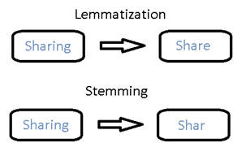

```python
display_image('lam-stem.png')
```

```python
from nltk.stem.porter import PorterStemmer
from nltk.stem import WordNetLemmatizer
from nltk.tokenize import word_tokenize
from nltk.corpus import stopwords

ps = PorterStemmer()
wml = WordNetLemmatizer()
Stopwords = set(stopwords.words('english'))

def cleaning_sentence(sentence):
    sentence_tokens = word_tokenize(sentence)
    cleaned_sentence = []
    for word in sentence_tokens:
        # Use only words, character combinations and numbers
        if (not word.isalpha() and not word.isnumeric()) and len(word) == 1:
            continue
        word = word.lower() # Lower case word
        if word in Stopwords: # Remove stop words
            continue
        stem_word = ps.stem(word) # Stem word
        cleaned_sentence.append(stem_word)
    return cleaned_sentence

print('Cleaned output should contain only words, numbers and character combinations.\nSingle characters (e.g. . , ( )) should be removed.')
print(cleaning_sentence("Hello World, 2 90° #SC (i am just checking how the 3/4 cleaning process work; random words: walk, talking, sitting, sat)."))
```

```
Cleaned output should contain only words, numbers and character combinations.
Single characters (e.g. . , ( )) should be removed.
['hello', 'world', '2', '90°', 'sc', 'check', '3/4', 'clean', 'process', 'work', 'random', 'word', 'walk', 'talk', 'sit', 'sat']
```

```python
%%time
from tqdm import tqdm

cleaned_corpus = np.array([cleaning_sentence(sentence) for sentence in tqdm(corpus, desc='Cleaning corpus')])
```

```
Wall time: 20min 14s
```

```python
corpus[:10]
```

```
array(['angle bracket', 'l bracket', 'deck over', 'rain shower head',
       'shower only faucet', 'convection otr', 'microwave over stove',
       'microwaves', 'emergency light', 'mdf 3/4'], dtype=object)
```

```python
print(cleaned_corpus[:10])

print(f'\nCleaned corpus size: {len(cleaned_corpus)}')
```

```
[list(['angl', 'bracket']) list(['l', 'bracket']) list(['deck'])
 list(['rain', 'shower', 'head']) list(['shower', 'faucet'])
 list(['convect', 'otr']) list(['microwav', 'stove']) list(['microwav'])
 list(['emerg', 'light']) list(['mdf', '3/4'])]

Cleaned corpus size: 372268
```

```python
%%time

word_freq, word_count = word_frequency_count(cleaned_corpus, split=False)
print(f'Unique words in cleaned corpus: {word_count}')
```

```
Unique words in cleaned corpus: 331034
Wall time: 7.12 s
```

```python
print('Most common words in cleaned corpus:')
print(sorted(word_freq, key=word_freq.get, reverse=True)[:10])
```

```
Most common words in cleaned corpus:
['use', 'design', 'instal', 'x', 'provid', 'easi', 'door', 'light', 'includ', 'finish']
```

```python
%%time
from keras.preprocessing.text import Tokenizer

def create_word_tokenizer(corpus):
    tokenizer = Tokenizer(char_level=False, lower=False)
    tokenizer.fit_on_texts(corpus)
    return tokenizer

word_tokenizer = create_word_tokenizer(cleaned_corpus)
```

```
Wall time: 19.4 s
```

```python
import random

word_keys = random.sample(word_tokenizer.word_index.keys(), 15)
print(f'Unique tokenized words in dictionary: {len(word_tokenizer.word_index.keys())}\n')
print({k:word_tokenizer.word_index[k] for k in word_keys})
```

```
Unique tokenized words in dictionary: 331034

{'tubing60': 63248, 'path12.0': 255460, 'lengthlow': 315262, 'margaux': 17024, 'toe-activ': 174791, 'areasceram': 192437, 'wdurabl': 252644, 'supportsupport': 183349, 'agentstop': 55388, 'necessarycaterpillar': 215103, 'barweath': 187896, 'connections.1/4': 110395, 'pre-installednot': 211055, 'gripp…
```

## 2.b. Create word embedding vectors

We will use word2vec model in order to produce vectorized representation for every word in out preprocesses corpus.

#### Word2Vec

Word2vec is a technique for natural language processing.  
The word2vec algorithm uses a neural network model to learn word associations from a large corpus of text.  
Once trained, such a model can detect synonymous words or suggest additional words for a partial sentence.  
As the name implies, word2vec represents each distinct word with a particular list of numbers called a vector.  
The vectors are chosen carefully such that a simple mathematical function (the cosine similarity between the vectors) indicates the level of semantic similarity between the words represented by those vectors.

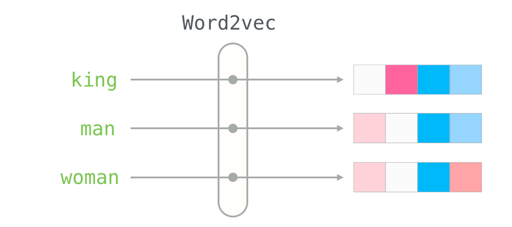

```python
display_image('word2vec.png')
```

```python
%%time
from gensim.models import word2vec

embedding_dim = 128
word2vec_model = word2vec.Word2Vec(cleaned_corpus, min_count=1, size=embedding_dim)
```

```
Wall time: 4min 51s
```

#### Simulate the word2vec word distance (or simillarity) on a 2D plane

```python
from sklearn.manifold import TSNE

def plot_word2vec_model(n=100, model=word2vec_model):
    vocab = list(model.wv.vocab)[:n]
    X = model[vocab]
    tsne = TSNE(n_components=2)
    X_tsne = tsne.fit_transform(X)
    df = pd.DataFrame(X_tsne, index=vocab, columns=['x', 'y'])
    fig = plt.figure(figsize=(20,20))
    ax = fig.add_subplot(1, 1, 1)
    ax.scatter(df['x'], df['y'])

    for word, pos in df.iterrows():
        ax.annotate(word, pos)
    plt.show()
```

```
C:\Users\Itay Bouganim\AppData\Roaming\Python\Python37\site-packages\ipykernel_launcher.py:5: DeprecationWarning: Call to deprecated `__getitem__` (Method will be removed in 4.0.0, use self.wv.__getitem__() instead).
  """
```

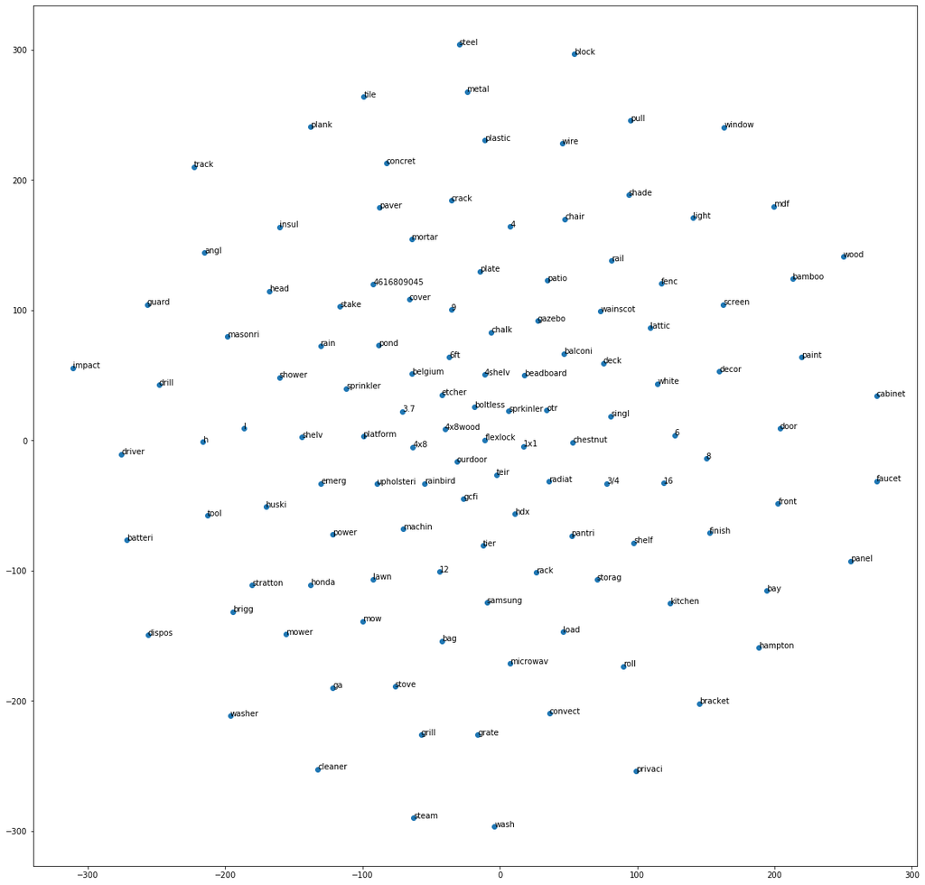

```python
plot_word2vec_model(n=125)
```

```python
word_keys = random.sample(word_tokenizer.word_index.keys(), 10)
print(f'Word2Vec dict sample: {len(word2vec_model.wv.vocab)}\n')
print({k:word2vec_model.wv.vocab[k] for k in word_keys})
```

```
Word2Vec dict sample: 331034

{'ventilationstainless': <gensim.models.keyedvectors.Vocab object at 0x000001A9BD3243C8>, 'materialfor': <gensim.models.keyedvectors.Vocab object at 0x000001A9ADDF2308>, 'resistance.they': <gensim.models.keyedvectors.Vocab object at 0x000001A9BC905C48>, 'safe.dimens': <gensim.models.keyedvectors.Voc…
```

```python
embedding_matrix = np.zeros((len(word_tokenizer.word_index) + 1, embedding_dim))
embedding_matrix[0] = 0  # Ignore padding

# Build the embedding matrix
for word, index in word_tokenizer.word_index.items():
    if word in word2vec_model.wv.vocab:
        embedding_matrix[index] = word2vec_model.wv.word_vec(word)

print(f'The embedding will be a vector representation\nfor every word in the cleaned corpus with size {embedding_dim}: {embedding_matrix.shape}')
```

```
The embedding will be a vector representation
for every word in the cleaned corpus with size 128: (331035, 128)
```

```python
def get_max_min_mean_words_len(col, df):
    l = np.array([len(cleaning_sentence(c)) for c in df[col]])
    return np.max(l), np.min(l), np.mean(l)

max_search_term_train, mn, mean_search_train = get_max_min_mean_words_len('search_term', train)
print(f'Max train data search term length: {max_search_term_train}')
print(f'Min train data search term length: {mn}')
print(f'Mean train data search term length: {mean_search_train}\n')

max_product_description_train, mn, mean_desc_train = get_max_min_mean_words_len('product_description', train)
print(f'Max train data product description length: {max_product_description_train}')
print(f'Min train data product description length: {mn}')
print(f'Mean train data product description length: {mean_desc_train}\n')

max_search_term, mn, mean = get_max_min_mean_words_len('search_term', test)
print(f'Max test data search term length: {max_search_term}')
print(f'Min test data search term length: {mn}')
print(f'Mean test data search term length: {mean}\n')

max_product_description, mn, mean = get_max_min_mean_words_len('product_description', test)
print(f'Max test data product description length: {max_product_description}')
print(f'Min test data product description length: {mn}')
print(f'Mean test data product description length: {mean}')
```

```
Max train data search term length: 11
Min train data search term length: 0
Mean train data search term length: 3.0278126561086585

Max train data product description length: 685
Min train data product description length: 16
Mean train data product description length: 92.61781900171466

Max test data search term length: 11
Min test data search term length: 0
Mean test data search term length: 3.021326527880643

Max test data product description length: 685
Min test data product description length: 1
Mean test data product description length: 93.15989541970428
```

```python
%%time
from keras.preprocessing.sequence import pad_sequences

cols = ['search_term', 'product_description', 'relevance']
padding_max_lens = {'search_term': max_search_term_train, 'product_description': math.trunc(mean_desc_train)}

def create_word_padded_sequences(df, tokenizer, padding_max_lens):
    df = df[cols].copy()
    for col in [col for col in cols if col != 'relevance']:
        sequences = tokenizer.texts_to_sequences([cleaning_sentence(c) for c in df[col]])
        padded_sequences = pad_sequences(sequences, maxlen=padding_max_lens[col], padding='post', truncating='post')
        df[col] = padded_sequences.tolist()
    df['relevance'] = df['relevance'].apply(normalize_relevance)
    return df
```

```
Wall time: 0 ns
```

```python
X_train_df = create_word_padded_sequences(train, tokenizer=word_tokenizer, padding_max_lens=padding_max_lens)
X_test_df = create_word_padded_sequences(test, tokenizer=word_tokenizer, padding_max_lens=padding_max_lens)
X_train_df
```

```
Wall time: 11min 36s
```

|  | search_term | product_description | relevance |
| --- | --- | --- | --- |
| 0 | [541, 395, 0, 0, 0, 0, 0, 0, 0, 0, 0] | [541, 29, 656, 1589, 93, 5, 640, 870, 367, 200... | 1.000 |
| 1 | [830, 395, 0, 0, 0, 0, 0, 0, 0, 0, 0] | [541, 29, 656, 1589, 93, 5, 640, 870, 367, 200... | 0.750 |
| 2 | [202, 0, 0, 0, 0, 0, 0, 0, 0, 0, 0] | [900, 299, 382, 7745, 508, 158, 25, 142, 482, ... | 1.000 |
| 3 | [868, 94, 254, 0, 0, 0, 0, 0, 0, 0, 0] | [1148, 152, 987, 7572, 2444, 94, 151, 129, 74,... | 0.665 |
| 4 | [94, 151, 0, 0, 0, 0, 0, 0, 0, 0, 0] | [1148, 152, 987, 7572, 2444, 94, 151, 129, 74,... | 0.835 |
| ... | ... | ... | ... |
| 74062 | [1283, 2137, 44, 0, 0, 0, 0, 0, 0, 0, 0] | [15424, 2917, 259931, 288, 2, 196, 1288, 77, 9... | 0.000 |
| 74063 | [6791, 1084, 8, 0, 0, 0, 0, 0, 0, 0, 0] | [1010, 62, 1944, 446, 1, 189, 62, 383, 461, 19... | 1.000 |
| 74064 | [2768, 136, 29137, 1612, 4837, 658, 0, 0, 0, 0... | [2768, 8529, 59565, 1520, 319, 5575, 2175, 351... | 0.665 |
| 74065 | [8297, 329, 64, 0, 0, 0, 0, 0, 0, 0, 0] | [2782, 329, 1286, 984, 2158, 10597, 2355, 2599... | 1.000 |
| 74066 | [1012, 5244, 1295, 4179, 559, 0, 0, 0, 0, 0, 0] | [12578, 25594, 22919, 12738, 382, 41305, 1295,... | 0.665 |

74067 rows × 3 columns

```python
%%time

data_cols = ['search_term', 'product_description']
X_train, y_train, X_valid, y_valid, X_test, y_test = create_X_y_splits(X_train_df, X_test_df, extract=True)

print("X, Y shapes:")
print(f'X train (search term: {X_train["search"].shape}, product description: {X_train["desc"].shape}), Y train: {y_train.shape}')
print(f'X valid (search term: {X_valid["search"].shape}, product description: {X_valid["desc"].shape}), Y valid: {y_valid.shape}')
print(f'X test (search term: {X_test["search"].shape}, product description: {X_test["desc"].shape}), Y test: {y_test.shape}')
```

```
X, Y shapes:
X train (search term: (59253, 11), product description: (59253, 92)), Y train: (59253,)
X valid (search term: (14814, 11), product description: (14814, 92)), Y valid: (14814,)
X test (search term: (112067, 11), product description: (112067, 92)), Y test: (112067,)
Wall time: 2.1 s
```

```python
X_train["search"].shape
```

```
(59253, 11)
```

```python
X_train_df
```

|  | search_term | product_description | relevance |
| --- | --- | --- | --- |
| 0 | [541, 395, 0, 0, 0, 0, 0, 0, 0, 0, 0] | [541, 29, 656, 1589, 93, 5, 640, 870, 367, 200... | 1.000 |
| 1 | [830, 395, 0, 0, 0, 0, 0, 0, 0, 0, 0] | [541, 29, 656, 1589, 93, 5, 640, 870, 367, 200... | 0.750 |
| 2 | [202, 0, 0, 0, 0, 0, 0, 0, 0, 0, 0] | [900, 299, 382, 7745, 508, 158, 25, 142, 482, ... | 1.000 |
| 3 | [868, 94, 254, 0, 0, 0, 0, 0, 0, 0, 0] | [1148, 152, 987, 7572, 2444, 94, 151, 129, 74,... | 0.665 |
| 4 | [94, 151, 0, 0, 0, 0, 0, 0, 0, 0, 0] | [1148, 152, 987, 7572, 2444, 94, 151, 129, 74,... | 0.835 |
| ... | ... | ... | ... |
| 74062 | [1283, 2137, 44, 0, 0, 0, 0, 0, 0, 0, 0] | [15424, 2917, 259931, 288, 2, 196, 1288, 77, 9... | 0.000 |
| 74063 | [6791, 1084, 8, 0, 0, 0, 0, 0, 0, 0, 0] | [1010, 62, 1944, 446, 1, 189, 62, 383, 461, 19... | 1.000 |
| 74064 | [2768, 136, 29137, 1612, 4837, 658, 0, 0, 0, 0... | [2768, 8529, 59565, 1520, 319, 5575, 2175, 351... | 0.665 |
| 74065 | [8297, 329, 64, 0, 0, 0, 0, 0, 0, 0, 0] | [2782, 329, 1286, 984, 2158, 10597, 2355, 2599... | 1.000 |
| 74066 | [1012, 5244, 1295, 4179, 559, 0, 0, 0, 0, 0, 0] | [12578, 25594, 22919, 12738, 382, 41305, 1295,... | 0.665 |

74067 rows × 3 columns

```python
X_train_df.to_csv('./X_train_df.csv', index=False)
X_test_df.to_csv('./X_test_df.csv', index=False)
```

```python
X_train_df = pd.read_csv('./X_train_df.csv')
X_test_df = pd.read_csv('./X_test_df.csv')
```

## 2.c. Training Word Level LSTM model

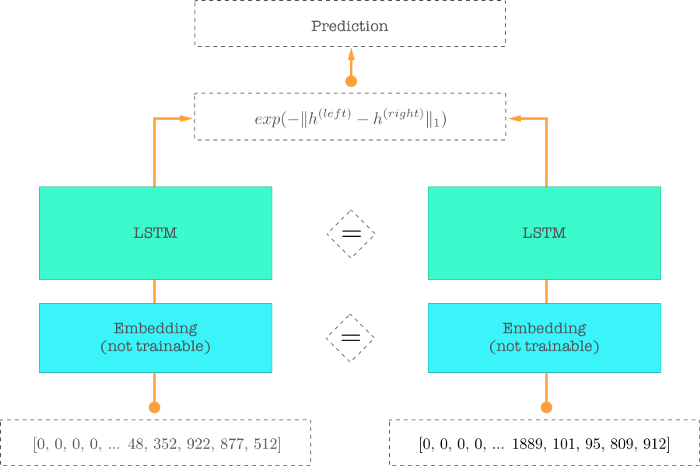

```python
display_image('malstm.png')
```

We will use cosine simillarity this time to measure simillarity:

#### Cosine Simillarity

Cosine similarity is a measure of similarity between two non-zero vectors of an inner product space.  
It is defined to equal the cosine of the angle between them, which is also the same as the inner product of the same vectors normalized to both have length 1.

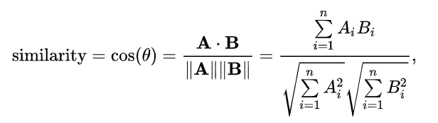

```python
display_image('cosine.png')
```

```python
from keras import backend as K

def cosine_distance(vests):
    x, y = vests
    x = K.l2_normalize(x, axis=-1)
    y = K.l2_normalize(y, axis=-1)
    return -K.mean(x * y, axis=-1, keepdims=True)

def cos_dist_output_shape(shapes):
    shape1, shape2 = shapes
    return (shape1[0],1)
```

For the word level model we will use Bidirectional LSTM with feed-forward to convolutional layer that will then produce a representation vector of size 128.

#### Bidirectional Recurrent Neural Networks

Bidirectional Recurrent Neural Networks (BRNN) connect two hidden layers of opposite directions to the same output.  
With this form of generative deep learning, the output layer can get information from past (backwards) and future (forward) states simultaneously.

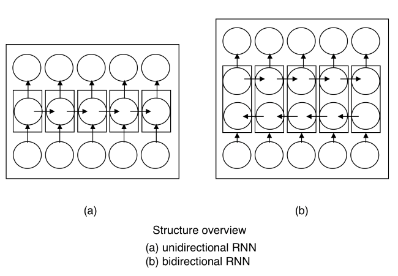

```python
display_image('bidirectional.png')
```

#### Using Individual models for inputs

Again, we will first try with individual models (one for each input) and combine them with both cosine simillarity and exponent manhattan distance.

```python
from keras.layers import Embedding, Conv1D, MaxPooling1D, Flatten, Concatenate, Dropout, GlobalAveragePooling1D, Bidirectional, Activation, Input, LSTM, Dense, Lambda
from keras.optimizers import Adadelta, Adam
from keras.models import Model
from tensorflow.keras.utils import plot_model
from keras.regularizers import l2

def word_siamese_model(input_shape, name, embedding_dim, embedding_matrix):
    inp = Input(shape=input_shape, dtype='int32')
    x = Embedding(len(embedding_matrix), embedding_dim, weights=[embedding_matrix], input_length=input_shape, trainable=False)(inp)
    x = Bidirectional(LSTM(128, return_sequences=True))(x)
    x = Conv1D(filters=32, kernel_size=8, strides=1, activation='relu', padding='same')(x)
    x = MaxPooling1D(3)(x)
    x = Activation('relu')(x)
    x = Flatten()(x)
    x = Dense(128, activation='relu')(x)
    return Model(inputs=inp, outputs=x, name=name)

ex_siamese_model = word_siamese_model(X_train['search'].shape[1], 'Example Siamese Model', embedding_dim=embedding_dim, embedding_matrix=embedding_matrix)
ex_siamese_model.summary()

def create_word_siamese_model(embedding_dim, embedding_matrix):
    search_inp = Input(shape=X_train['search'].shape[1], dtype='int32')
    desc_inp = Input(shape=X_train['desc'].shape[1], dtype='int32')
    search_model = word_siamese_model(input_shape=X_train['search'].shape[1], name='search_siamese',
                                      embedding_dim=embedding_dim, embedding_matrix=embedding_matrix)(search_inp)
    desc_model = word_siamese_model(input_shape=X_train['desc'].shape[1], name='description_siamese',
                                    embedding_dim=embedding_dim, embedding_matrix=embedding_matrix)(desc_inp)
    malstm = Lambda(function=lambda x: exponent_neg_manhattan_distance(x[0], x[1]), output_shape=lambda x: (x[0][0], 1))([search_model, desc_model])
    cosine = Lambda(cosine_distance, output_shape=cos_dist_output_shape)([search_model, desc_model])
    conc = Concatenate(axis=-1)([malstm, cosine])
    x = Dense(100, activation="relu", name='conc_layer')(conc)
    x = Dropout(0.05)(x)
    y = Dense(1, activation='sigmoid')(x)

    model = Model([search_inp, desc_inp], y)
    model.compile(loss=root_mean_squared_error, optimizer='adam', metrics=['accuracy', 'mse', 'mae', root_mean_squared_error])
    return model

siamese_word_seq_model = create_word_siamese_model(embedding_dim, embedding_matrix)
siamese_word_seq_model.summary()
```

```
Model: "Example Siamese Model"
_________________________________________________________________
Layer (type)                 Output Shape              Param #
=================================================================
input_1 (InputLayer)         [(None, 11)]              0
_________________________________________________________________
embedding (Embedding)        (None, 11, 128)           42372480
_________________________________________________________________
bidirectional (Bidirectional (None, 11, 256)           263168
_________________________________________________________________
conv1d (Conv1D)              (None, 11, 32)            65568
_________________________________________________________________
max_pooling1d (MaxPooling1D) (None, 3, 32)             0
_________________________________________________________________
activation (Activation)      (None, 3, 32)             0
_________________________________________________________________
flatten (Flatten)            (None, 96)                0
_________________________________________________________________
dense (Dense)                (None, 128)               12416
=================================================================
Total params: 42,713,632
Trainable params: 341,152
Non-trainable params: 42,372,480
_________________________________________________________________
Model: "functional_1"
__________________________________________________________________________________________________
Layer (type)                    Output Shape         Param #     Connected to
==================================================================================================
input_2 (InputLayer)            [(None, 11)]         0
__________________________________________________________________________________________________
input_3 (InputLayer)            [(None, 92)]         0
__________________________________________________________________________________________________
search_siamese (Functional)     (None, 128)          42713632    input_2[0][0]
__________________________________________________________________________________________________
description_siamese (Functional (None, 128)          42824224    input_3[0][0]
__________________________________________________________________________________________________
lambda (Lambda)                 (None, 1)            0           search_siamese[0][0]
                                                                 description_siamese[0][0]
__________________________________________________________________________________________________
lambda_1 (Lambda)               (None, 1)            0           search_siamese[0][0]
                                                                 description_siamese[0][0]
__________________________________________________________________________________________________
concatenate (Concatenate)       (None, 2)            0           lambda[0][0]
                                                                 lambda_1[0][0]
__________________________________________________________________________________________________
conc_layer (Dense)              (None, 100)          300         concatenate[0][0]
__________________________________________________________________________________________________
dropout (Dropout)               (None, 100)          0           conc_layer[0][0]
__________________________________________________________________________________________________
dense_3 (Dense)                 (None, 1)            101         dropout[0][0]
==================================================================================================
Total params: 85,538,257
Trainable params: 793,297
Non-trainable params: 84,744,960
__________________________________________________________________________________________________
```

```python
history = siamese_word_seq_model.fit((X_train['search'], X_train['desc']), y_train, batch_size=256, epochs=40,
                            validation_data=((X_valid['search'], X_valid['desc']), y_valid), callbacks=get_callbacks('word_seq_siamese'))
save_history(history, 'word_seq_siamese')
```

```
Epoch 00001: val_loss improved from inf to 0.26607, saving model to ./saved_models\model_word_seq_siamese.h5
Epoch 00002: val_loss improved from 0.26607 to 0.26571, saving model to ./saved_models\model_word_seq_siamese.h5
Epoch 00003: val_loss improved from 0.26571 to 0.26490, saving model to ./saved_models\model_word_seq_siamese.h5
Epoch 00004: val_loss improved from 0.26490 to 0.26368, saving model to ./saved_models\model_word_seq_siamese.h5
Epoch 00005: val_loss improved from 0.26368 to 0.26172, saving model to ./saved_models\model_word_seq_siamese.h5
Epoch 00006: val_loss improved from 0.26172 to 0.25959, saving model to ./saved_models\model_word_seq_siamese.h5
Epoch 00007: val_loss improved from 0.25959 to 0.25690, saving model to ./saved_models\model_word_seq_siamese.h5
Epoch 00008: val_loss improved from 0.25690 to 0.25499, saving model to ./saved_models\model_word_seq_siamese.h5
Epoch 00009: val_loss improved from 0.25499 to 0.25294, saving model to ./saved_models\model_word_seq_siamese.h5
Epoch 00010: val_loss improved from 0.25294 to 0.25129, saving model to ./saved_models\model_word_seq_siamese.h5
Epoch 00011: val_loss improved from 0.25129 to 0.24982, saving model to ./saved_models\model_word_seq_siamese.h5
Epoch 00012: val_loss improved from 0.24982 to 0.24794, saving model to ./saved_models\model_word_seq_siamese.h5
Epoch 00013: val_loss improved from 0.24794 to 0.24697, saving model to ./saved_models\model_word_seq_siamese.h5
Epoch 00014: val_loss improved from 0.24697 to 0.24499, saving model to ./saved_models\model_word_seq_siamese.h5
Epoch 00015: val_loss improved from 0.24499 to 0.24279, saving model to ./saved_models\model_word_seq_siamese.h5
Epoch 00016: val_loss improved from 0.24279 to 0.24100, saving model to ./saved_models\model_word_seq_siamese.h5
Epoch 00017: val_loss improved from 0.24100 to 0.24053, saving model to ./saved_models\model_word_seq_siamese.h5
Epoch 00018: val_loss did not improve from 0.24053
Epoch 00019: val_loss did not improve from 0.24053
Epoch 00020: val_loss did not improve from 0.24053
Epoch 00021: val_loss did not improve from 0.24053
Epoch 00022: val_loss did not improve from 0.24053
Epoch 00022: early stopping
```

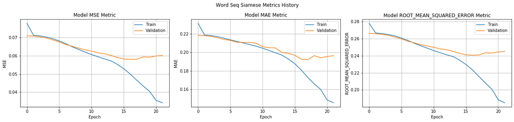

```python
plot_model_history(model_name='word_seq_siamese')
```

```python
calculate_model_results(lambda: create_word_siamese_model(embedding_dim, embedding_matrix), 'word_seq_siamese', X_test, X_train, X_valid, y_test, y_train, y_valid)
```

```
Test data results:
Word Seq Siamese RMSE: 0.2635100872257146
Word Seq Siamese MSE: 0.06943756606970372
Word Seq Siamese MAE: 0.21107161651310402

Validation data results:
Word Seq Siamese RMSE: 0.2407452175820478
Word Seq Siamese MSE: 0.057958259788627536
Word Seq Siamese MAE: 0.19267459909668394

Train data results:
Word Seq Siamese RMSE: 0.21502652804767838
Word Seq Siamese MSE: 0.04623640776423902
Word Seq Siamese MAE: 0.17089774222985007
```

#### We will try to expirement with larger embedding vector dimensions for each word (128 -> 512) to see if we can get better results

```python
%%time
from gensim.models import word2vec

embedding_large_dim = 512
word2vec_large_model = word2vec.Word2Vec(cleaned_corpus, min_count=1, size=embedding_large_dim)
```

```
Wall time: 6min 25s
```

```
C:\Users\Itay Bouganim\AppData\Roaming\Python\Python37\site-packages\ipykernel_launcher.py:5: DeprecationWarning: Call to deprecated `__getitem__` (Method will be removed in 4.0.0, use self.wv.__getitem__() instead).
  """
```

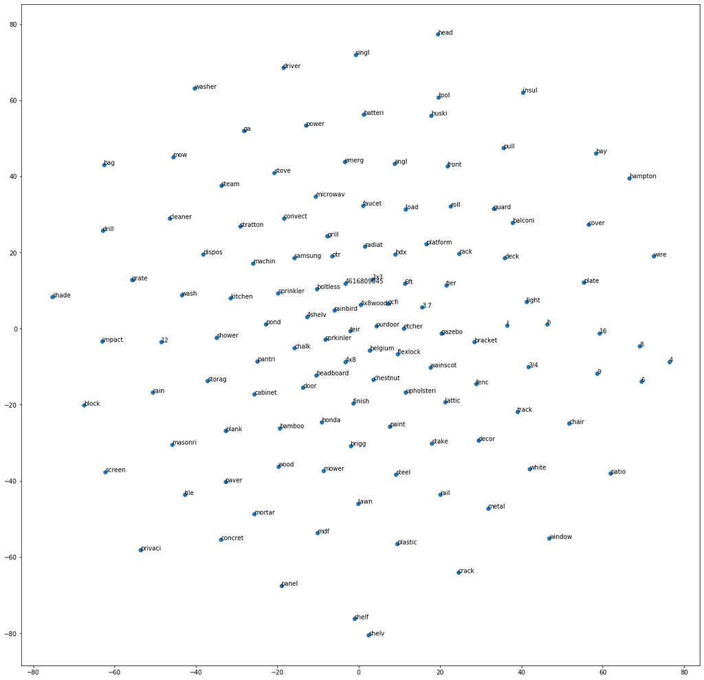

```python
plot_word2vec_model(n=125, model=word2vec_large_model)
```

```python
embedding_matrix_large = np.zeros((len(word_tokenizer.word_index) + 1, embedding_large_dim))
embedding_matrix_large[0] = 0  # Ignore padding

# Build the embedding matrix
for word, index in word_tokenizer.word_index.items():
    if word in word2vec_large_model.wv.vocab:
        embedding_matrix_large[index] = word2vec_large_model.wv.word_vec(word)

print(f'The embedding will be a vector representation\nfor every word in the cleaned corpus with size {embedding_large_dim}: {embedding_matrix_large.shape}')
```

```
The embedding will be a vector representation
for every word in the cleaned corpus with size 512: (331035, 512)
```

```python
siamese_word_seq_large_emb_model = create_word_siamese_model(embedding_large_dim, embedding_matrix_large)
siamese_word_seq_large_emb_model.summary()
```

```
Model: "functional_3"
__________________________________________________________________________________________________
Layer (type)                    Output Shape         Param #     Connected to
==================================================================================================
input_6 (InputLayer)            [(None, 11)]         0
__________________________________________________________________________________________________
input_7 (InputLayer)            [(None, 92)]         0
__________________________________________________________________________________________________
search_siamese (Functional)     (None, 128)          170224288   input_6[0][0]
__________________________________________________________________________________________________
description_siamese (Functional (None, 128)          170334880   input_7[0][0]
__________________________________________________________________________________________________
lambda_2 (Lambda)               (None, 1)            0           search_siamese[0][0]
                                                                 description_siamese[0][0]
__________________________________________________________________________________________________
lambda_3 (Lambda)               (None, 1)            0           search_siamese[0][0]
                                                                 description_siamese[0][0]
__________________________________________________________________________________________________
concatenate_1 (Concatenate)     (None, 2)            0           lambda_2[0][0]
                                                                 lambda_3[0][0]
__________________________________________________________________________________________________
conc_layer (Dense)              (None, 100)          300         concatenate_1[0][0]
__________________________________________________________________________________________________
dropout_1 (Dropout)             (None, 100)          0           conc_layer[0][0]
__________________________________________________________________________________________________
dense_6 (Dense)                 (None, 1)            101         dropout_1[0][0]
==================================================================================================
Total params: 340,559,569
Trainable params: 1,579,729
Non-trainable params: 338,979,840
__________________________________________________________________________________________________
```

```python
history = siamese_word_seq_large_emb_model.fit((X_train['search'], X_train['desc']), y_train, batch_size=256, epochs=40,
                            validation_data=((X_valid['search'], X_valid['desc']), y_valid), callbacks=get_callbacks('word_seq_large_siamese'))
save_history(history, 'word_seq_large_siamese')
```

```
Epoch 00001: val_loss improved from inf to 0.26789, saving model to ./saved_models\model_word_seq_large_siamese.h5
Epoch 00002: val_loss improved from 0.26789 to 0.26769, saving model to ./saved_models\model_word_seq_large_siamese.h5
Epoch 00003: val_loss improved from 0.26769 to 0.26743, saving model to ./saved_models\model_word_seq_large_siamese.h5
Epoch 00004: val_loss improved from 0.26743 to 0.26713, saving model to ./saved_models\model_word_seq_large_siamese.h5
Epoch 00005: val_loss improved from 0.26713 to 0.26681, saving model to ./saved_models\model_word_seq_large_siamese.h5
Epoch 00006: val_loss improved from 0.26681 to 0.26616, saving model to ./saved_models\model_word_seq_large_siamese.h5
Epoch 00007: val_loss improved from 0.26616 to 0.26550, saving model to ./saved_models\model_word_seq_large_siamese.h5
Epoch 00008: val_loss improved from 0.26550 to 0.26461, saving model to ./saved_models\model_word_seq_large_siamese.h5
Epoch 00009: val_loss improved from 0.26461 to 0.26376, saving model to ./saved_models\model_word_seq_large_siamese.h5
Epoch 00010: val_loss improved from 0.26376 to 0.26227, saving model to ./saved_models\model_word_seq_large_siamese.h5
Epoch 00011: val_loss improved from 0.26227 to 0.26143, saving model to ./saved_models\model_word_seq_large_siamese.h5
Epoch 00012: val_loss improved from 0.26143 to 0.25897, saving model to ./saved_models\model_word_seq_large_siamese.h5
Epoch 00013: val_loss improved from 0.25897 to 0.25673, saving model to ./saved_models\model_word_seq_large_siamese.h5
Epoch 00014: val_loss improved from 0.25673 to 0.25516, saving model to ./saved_models\model_word_seq_large_siamese.h5
Epoch 00015: val_loss improved from 0.25516 to 0.25320, saving model to ./saved_models\model_word_seq_large_siamese.h5
Epoch 00016: val_loss improved from 0.25320 to 0.25170, saving model to ./saved_models\model_word_seq_large_siamese.h5
Epoch 00017: val_loss improved from 0.25170 to 0.25024, saving model to ./saved_models\model_word_seq_large_siamese.h5
Epoch 00018: val_loss improved from 0.25024 to 0.24863, saving model to ./saved_models\model_word_seq_large_siamese.h5
Epoch 00019: val_loss improved from 0.24863 to 0.24743, saving model to ./saved_models\model_word_seq_large_siamese.h5
Epoch 00020: val_loss improved from 0.24743 to 0.24611, saving model to ./saved_models\model_word_seq_large_siamese.h5
Epoch 00021: val_loss improved from 0.24611 to 0.24533, saving model to ./saved_models\model_word_seq_large_siamese.h5
Epoch 00022: val_loss did not improve from 0.24533
Epoch 00023: val_loss did not improve from 0.24533
Epoch 00024: val_loss did not improve from 0.24533
Epoch 00025: val_loss did not improve from 0.24533
Epoch 00026: val_loss did not improve from 0.24533
Epoch 00026: early stopping
```

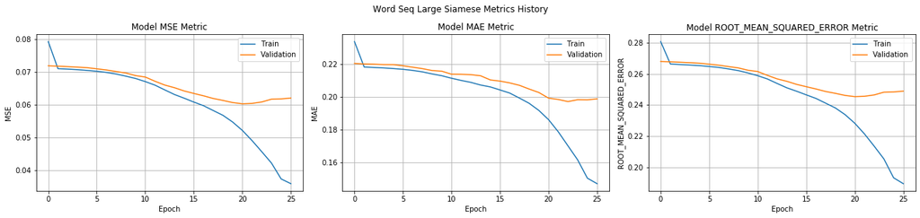

```python
plot_model_history(model_name='word_seq_large_siamese')
```

```python
calculate_model_results(lambda: create_word_siamese_model(embedding_large_dim, embedding_matrix_large), 'word_seq_large_siamese', X_test, X_train, X_valid, y_test, y_train, y_valid)
```

```
Test data results:
Word Seq Large Siamese RMSE: 0.2618027554262483
Word Seq Large Siamese MSE: 0.06854068274877598
Word Seq Large Siamese MAE: 0.21221592030787353

Validation data results:
Word Seq Large Siamese RMSE: 0.24560258921785827
Word Seq Large Siamese MSE: 0.06032063183051603
Word Seq Large Siamese MAE: 0.1993638936268168

Train data results:
Word Seq Large Siamese RMSE: 0.22067101074443726
Word Seq Large Siamese MSE: 0.04869569498297154
Word Seq Large Siamese MAE: 0.17764586276827632
```

### Using a true siamese network

Next we will try to train the same model for the two inputs so that the model share the trained weights for both inputs.

#### Working with same size words input vector

We will try making the two words input vectors (search terms and descriptions) the same length.  
We will take the mean description word count as both vector length.

```python
%%time
from keras.preprocessing.sequence import pad_sequences

cols = ['search_term', 'product_description', 'relevance']
padding_max_lens = {'search_term': math.trunc(mean_desc_train), 'product_description': math.trunc(mean_desc_train)}

X_train_df = create_word_padded_sequences(train, tokenizer=word_tokenizer, padding_max_lens=padding_max_lens)
X_test_df = create_word_padded_sequences(test, tokenizer=word_tokenizer, padding_max_lens=padding_max_lens)
X_train_df
```

```
Wall time: 22min 15s
```

|  | search_term | product_description | relevance |
| --- | --- | --- | --- |
| 0 | [541, 395, 0, 0, 0, 0, 0, 0, 0, 0, 0, 0, 0, 0,... | [541, 29, 656, 1589, 93, 5, 640, 870, 367, 200... | 1.000 |
| 1 | [830, 395, 0, 0, 0, 0, 0, 0, 0, 0, 0, 0, 0, 0,... | [541, 29, 656, 1589, 93, 5, 640, 870, 367, 200... | 0.750 |
| 2 | [202, 0, 0, 0, 0, 0, 0, 0, 0, 0, 0, 0, 0, 0, 0... | [900, 299, 382, 7745, 508, 158, 25, 142, 482, ... | 1.000 |
| 3 | [868, 94, 254, 0, 0, 0, 0, 0, 0, 0, 0, 0, 0, 0... | [1148, 152, 987, 7572, 2444, 94, 151, 129, 74,... | 0.665 |
| 4 | [94, 151, 0, 0, 0, 0, 0, 0, 0, 0, 0, 0, 0, 0, ... | [1148, 152, 987, 7572, 2444, 94, 151, 129, 74,... | 0.835 |
| ... | ... | ... | ... |
| 74062 | [1283, 2137, 44, 0, 0, 0, 0, 0, 0, 0, 0, 0, 0,... | [15424, 2917, 259931, 288, 2, 196, 1288, 77, 9... | 0.000 |
| 74063 | [6791, 1084, 8, 0, 0, 0, 0, 0, 0, 0, 0, 0, 0, ... | [1010, 62, 1944, 446, 1, 189, 62, 383, 461, 19... | 1.000 |
| 74064 | [2768, 136, 29137, 1612, 4837, 658, 0, 0, 0, 0... | [2768, 8529, 59565, 1520, 319, 5575, 2175, 351... | 0.665 |
| 74065 | [8297, 329, 64, 0, 0, 0, 0, 0, 0, 0, 0, 0, 0, ... | [2782, 329, 1286, 984, 2158, 10597, 2355, 2599... | 1.000 |
| 74066 | [1012, 5244, 1295, 4179, 559, 0, 0, 0, 0, 0, 0... | [12578, 25594, 22919, 12738, 382, 41305, 1295,... | 0.665 |

74067 rows × 3 columns

```python
%%time

data_cols = ['search_term', 'product_description']
X_train, y_train, X_valid, y_valid, X_test, y_test = create_X_y_splits(X_train_df, X_test_df, extract=True)

print("X, Y shapes:")
print(f'X train (search term: {X_train["search"].shape}, product description: {X_train["desc"].shape}), Y train: {y_train.shape}')
print(f'X valid (search term: {X_valid["search"].shape}, product description: {X_valid["desc"].shape}), Y valid: {y_valid.shape}')
print(f'X test (search term: {X_test["search"].shape}, product description: {X_test["desc"].shape}), Y test: {y_test.shape}')
```

```
X, Y shapes:
X train (search term: (59253, 92), product description: (59253, 92)), Y train: (59253,)
X valid (search term: (14814, 92), product description: (14814, 92)), Y valid: (14814,)
X test (search term: (112067, 92), product description: (112067, 92)), Y test: (112067,)
Wall time: 5.37 s
```

#### Increasing the Convolutional layers depth and working with common siamese layers

We will use common siamese models by using the same layers in order to share the layers weights.  
Also, we will increase the convolutional layers depth and filters (the output from the biderectional LSTM will be the input for the convolution).

```python
from keras.layers import Embedding, Conv1D, MaxPooling1D, Flatten, Concatenate, Dropout, Bidirectional, Activation, Input, LSTM, Dense, Lambda, GlobalMaxPooling1D
from keras.optimizers import Adadelta, Adam
from keras.models import Model
from tensorflow.keras.utils import plot_model
from keras.regularizers import l2

def create_word_siamese_joined_model(embedding_dim, embedding_matrix):
    search_inp = Input(shape=X_train['search'].shape[1], dtype='int32')
    desc_inp = Input(shape=X_train['desc'].shape[1], dtype='int32')
    # Siamese model part with joined weights
    emb = Embedding(len(embedding_matrix), embedding_dim, weights=[embedding_matrix],
                    input_length=max([X_train['search'].shape[1], X_train['desc'].shape[1]]), trainable=False)
    search_emb = emb(search_inp)
    desc_emb = emb(desc_inp)
    lstm = Bidirectional(LSTM(128, return_sequences=True))
    x1 = lstm(search_emb)
    x2 = lstm(desc_emb)
    lstm2 = Bidirectional(LSTM(128, return_sequences=True))
    x1 = lstm2(x1)
    x2 = lstm2(x2)
    conv = Conv1D(filters=128, kernel_size=3, strides=1, activation='relu', padding='same')
    conv2 = Conv1D(filters=128, kernel_size=3, strides=1, activation='relu', padding='same')
    x1 = conv(x1)
    x2 = conv(x2)
    x1 = conv2(x1)
    x2 = conv2(x2)
    mx = MaxPooling1D(3)
    x1 = mx(x1)
    x2 = mx(x2)
    act = Activation('relu')
    x1 = act(x1)
    x2 = act(x2)
    flat = Flatten()
    x1 = flat(x1)
    x2 = flat(x2)
    d = Dense(128, activation='relu')
    x1 = d(x1)
    x2 = d(x2)
    # Output vector simillarity
    cosine = Lambda(cosine_distance, output_shape=cos_dist_output_shape)([x1, x2])
    y = Dense(1, activation='sigmoid')(cosine)

    model = Model([search_inp, desc_inp], y)
    model.compile(loss=root_mean_squared_error, optimizer='adam', metrics=['accuracy', 'mse', 'mae', root_mean_squared_error])
    return model

siamese_word_seq_joined_model = create_word_siamese_joined_model(embedding_large_dim, embedding_matrix_large)
siamese_word_seq_joined_model.summary()
```

```
Model: "functional_9"
__________________________________________________________________________________________________
Layer (type)                    Output Shape         Param #     Connected to
==================================================================================================
input_11 (InputLayer)           [(None, 92)]         0
__________________________________________________________________________________________________
input_12 (InputLayer)           [(None, 92)]         0
__________________________________________________________________________________________________
embedding_5 (Embedding)         (None, 92, 512)      169489920   input_11[0][0]
                                                                 input_12[0][0]
__________________________________________________________________________________________________
bidirectional_5 (Bidirectional) (None, 92, 256)      656384      embedding_5[0][0]
                                                                 embedding_5[1][0]
__________________________________________________________________________________________________
bidirectional_6 (Bidirectional) (None, 92, 256)      394240      bidirectional_5[0][0]
                                                                 bidirectional_5[1][0]
__________________________________________________________________________________________________
conv1d_8 (Conv1D)               (None, 92, 128)      98432       bidirectional_6[0][0]
                                                                 bidirectional_6[1][0]
__________________________________________________________________________________________________
conv1d_9 (Conv1D)               (None, 92, 128)      49280       conv1d_8[0][0]
                                                                 conv1d_8[1][0]
__________________________________________________________________________________________________
max_pooling1d_2 (MaxPooling1D)  (None, 30, 128)      0           conv1d_9[0][0]
                                                                 conv1d_9[1][0]
__________________________________________________________________________________________________
activation_2 (Activation)       (None, 30, 128)      0           max_pooling1d_2[0][0]
                                                                 max_pooling1d_2[1][0]
__________________________________________________________________________________________________
flatten_3 (Flatten)             (None, 3840)         0           activation_2[0][0]
                                                                 activation_2[1][0]
__________________________________________________________________________________________________
dense_7 (Dense)                 (None, 128)          491648      flatten_3[0][0]
                                                                 flatten_3[1][0]
__________________________________________________________________________________________________
lambda_4 (Lambda)               (None, 1)            0           dense_7[0][0]
                                                                 dense_7[1][0]
__________________________________________________________________________________________________
dense_8 (Dense)                 (None, 1)            2           lambda_4[0][0]
==================================================================================================
Total params: 171,179,906
Trainable params: 1,689,986
Non-trainable params: 169,489,920
__________________________________________________________________________________________________
```

```python
history = siamese_word_seq_joined_model.fit((X_train['search'], X_train['desc']), y_train, batch_size=32, epochs=40,
                            validation_data=((X_valid['search'], X_valid['desc']), y_valid), callbacks=get_callbacks('word_seq_joined_siamese'))
save_history(history, 'word_seq_joined_siamese')
```

```
Epoch 00001: val_loss improved from inf to 0.26546, saving model to ./saved_models\model_word_seq_joined_siamese.h5
Epoch 00002: val_loss improved from 0.26546 to 0.26542, saving model to ./saved_models\model_word_seq_joined_siamese.h5
Epoch 00003: val_loss improved from 0.26542 to 0.26534, saving model to ./saved_models\model_word_seq_joined_siamese.h5
Epoch 00004: val_loss improved from 0.26534 to 0.26531, saving model to ./saved_models\model_word_seq_joined_siamese.h5
Epoch 00005: val_loss did not improve from 0.26531
Epoch 00006: val_loss improved from 0.26531 to 0.26516, saving model to ./saved_models\model_word_seq_joined_siamese.h5
Epoch 00007: val_loss did not improve from 0.26516
Epoch 00008: val_loss improved from 0.26516 to 0.26491, saving model to ./saved_models\model_word_seq_joined_siamese.h5
Epoch 00009: val_loss improved from 0.26491 to 0.26472, saving model to ./saved_models\model_word_seq_joined_siamese.h5
Epoch 00010: val_loss improved from 0.26472 to 0.26468, saving model to ./saved_models\model_word_seq_joined_siamese.h5
Epoch 00011: val_loss improved from 0.26468 to 0.26445, saving model to ./saved_models\model_word_seq_joined_siamese.h5
Epoch 00012: val_loss improved from 0.26445 to 0.26438, saving model to ./saved_models\model_word_seq_joined_siamese.h5
Epoch 00013: val_loss improved from 0.26438 to 0.26421, saving model to ./saved_models\model_word_seq_joined_siamese.h5
Epoch 00014: val_loss improved from 0.26421 to 0.26410, saving model to ./saved_models\model_word_seq_joined_siamese.h5
Epoch 00015: val_loss did not improve from 0.26410
Epoch 00016: val_loss did not improve from 0.26410
Epoch 00017: val_loss improved from 0.26410 to 0.26374, saving model to ./saved_models\model_word_seq_joined_siamese.h5
Epoch 00018: val_loss improved from 0.26374 to 0.26369, saving model to ./saved_models\model_word_seq_joined_siamese.h5
Epoch 00019: val_loss improved from 0.26369 to 0.26349, saving model to ./saved_models\model_word_seq_joined_siamese.h5
Epoch 00020: val_loss did not improve from 0.26349
Epoch 00021: val_loss improved from 0.26349 to 0.26337, saving model to ./saved_models\model_word_seq_joined_siamese.h5
Epoch 00022: val_loss did not improve from 0.26337
Epoch 00023: val_loss improved from 0.26337 to 0.26302, saving model to ./saved_models\model_word_seq_joined_siamese.h5
Epoch 00024: val_loss improved from 0.26302 to 0.26263, saving model to ./saved_models\model_word_seq_joined_siamese.h5
Epoch 00025: val_loss improved from 0.26263 to 0.26239, saving model to ./saved_models\model_word_seq_joined_siamese.h5
Epoch 00026: val_loss improved from 0.26239 to 0.26221, saving model to ./saved_models\model_word_seq_joined_siamese.h5
Epoch 00027: val_loss improved from 0.26221 to 0.26196, saving model to ./saved_models\model_word_seq_joined_siamese.h5
Epoch 00028: val_loss improved from 0.26196 to 0.26162, saving model to ./saved_models\model_word_seq_joined_siamese.h5
Epoch 00029: val_loss improved from 0.26162 to 0.26140, saving model to ./saved_models\model_word_seq_joined_siamese.h5
Epoch 00030: val_loss improved from 0.26140 to 0.26131, saving model to ./saved_models\model_word_seq_joined_siamese.h5
Epoch 00031: val_loss did not improve from 0.26131
Epoch 00032: val_loss improved from 0.26131 to 0.26116, saving model to ./saved_models\model_word_seq_joined_siamese.h5
Epoch 00033: val_loss improved from 0.26116 to 0.26062, saving model to ./saved_models\model_word_seq_joined_siamese.h5
Epoch 00034: val_loss did not improve from 0.26062
Epoch 00035: val_loss improved from 0.26062 to 0.26016, saving model to ./saved_models\model_word_seq_joined_siamese.h5
Epoch 00036: val_loss improved from 0.26016 to 0.26004, saving model to ./saved_models\model_word_seq_joined_siamese.h5
Epoch 00037: val_loss improved from 0.26004 to 0.25984, saving model to ./saved_models\model_word_seq_joined_siamese.h5
Epoch 00038: val_loss improved from 0.25984 to 0.25950, saving model to ./saved_models\model_word_seq_joined_siamese.h5
Epoch 00039: val_loss did not improve from 0.25950
Epoch 00040: val_loss improved from 0.25950 to 0.25913, saving model to ./saved_models\model_word_seq_joined_siamese.h5
```

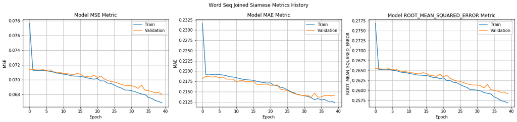

```python
plot_model_history(model_name='word_seq_joined_siamese')
```

```python
calculate_model_results(lambda: create_word_siamese_joined_model(embedding_large_dim, embedding_matrix_large), 'word_seq_joined_siamese', X_test, X_train, X_valid, y_test, y_train, y_valid)
```

```
Test data results:
Word Seq Joined Siamese RMSE: 0.26387441828132885
Word Seq Joined Siamese MSE: 0.0696297086233097
Word Seq Joined Siamese MAE: 0.21735656760481345

Validation data results:
Word Seq Joined Siamese RMSE: 0.26080213837719046
Word Seq Joined Siamese MSE: 0.0680177553821152
Word Seq Joined Siamese MAE: 0.21418499618998035

Train data results:
Word Seq Joined Siamese RMSE: 0.25811213134864436
Word Seq Joined Siamese MSE: 0.06662187234933985
Word Seq Joined Siamese MAE: 0.21271295076768296
```

## 2.d. Feature extraction from the Word Level LSTM model to classical ML algorithms

```python
siamese_word_seq_model_fe = create_word_siamese_model(embedding_large_dim, embedding_matrix_large)
siamese_word_seq_model_fe.load_weights(join(model_save_dir, f'model_word_seq_large_siamese.h5'))
siamese_word_seq_model_fe = Model(siamese_word_seq_model_fe.inputs, siamese_word_seq_model_fe.layers[-2].output)
siamese_word_seq_model_fe.summary()
```

```
Model: "functional_9"
__________________________________________________________________________________________________
Layer (type)                    Output Shape         Param #     Connected to
==================================================================================================
input_14 (InputLayer)           [(None, 11)]         0
__________________________________________________________________________________________________
input_15 (InputLayer)           [(None, 92)]         0
__________________________________________________________________________________________________
search_siamese (Functional)     (None, 128)          170224288   input_14[0][0]
__________________________________________________________________________________________________
description_siamese (Functional (None, 128)          170334880   input_15[0][0]
__________________________________________________________________________________________________
lambda_6 (Lambda)               (None, 1)            0           search_siamese[0][0]
                                                                 description_siamese[0][0]
__________________________________________________________________________________________________
lambda_7 (Lambda)               (None, 1)            0           search_siamese[0][0]
                                                                 description_siamese[0][0]
__________________________________________________________________________________________________
concatenate_3 (Concatenate)     (None, 2)            0           lambda_6[0][0]
                                                                 lambda_7[0][0]
__________________________________________________________________________________________________
conc_layer (Dense)              (None, 100)          300         concatenate_3[0][0]
__________________________________________________________________________________________________
dropout_3 (Dropout)             (None, 100)          0           conc_layer[0][0]
==================================================================================================
Total params: 340,559,468
Trainable params: 1,579,628
Non-trainable params: 338,979,840
__________________________________________________________________________________________________
```

```python
preds = siamese_word_seq_model_fe.predict((X_train['search'], X_train['desc']), verbose=1)
```

```python
from xgboost import XGBRegressor

xgboost_model = XGBRegressor(n_estimators=100, verbosity=1, eval_metric='rmse', objective='reg:squarederror')
xgboost_model.fit(preds, y_train)
```

```
XGBRegressor(base_score=0.5, booster='gbtree', colsample_bylevel=1,
             colsample_bynode=1, colsample_bytree=1, eval_metric='rmse',
             gamma=0, gpu_id=-1, importance_type='gain',
             interaction_constraints='', learning_rate=0.300000012,
             max_delta_step=0, max_depth=6, min_child_weight=1, missing=nan,
             monotone_constraints='()', n_estimators=100, n_jobs=8,
             num_parallel_tree=1, random_state=0, reg_alpha=0, reg_lambda=1,
             scale_pos_weight=1, subsample=1, tree_method='exact',
             validate_parameters=1, verbosity=1)
```

```python
fe_ml_model_scores(model_name='xgboost word model', ml_model=xgboost_model, fe_model=siamese_word_seq_model_fe)
```

```
Test data results:
xgboost word model RMSE: 0.2687339463187322
xgboost word model MSE: 0.07221793390403923
xgboost word model MAE: 0.2148875198089219

Validation data results:
xgboost word model RMSE: 0.2497396072957575
xgboost word model MSE: 0.06236987145223917
xgboost word model MAE: 0.19896083725477273

Train data results:
xgboost word model RMSE: 0.21074713926888536
xgboost word model MSE: 0.044414356710018955
xgboost word model MAE: 0.16525269131751963
```

```python
from catboost import CatBoostRegressor

catboost_model = CatBoostRegressor(iterations=100, learning_rate=0.5)
catboost_model.fit(preds, y_train)
```

[output not shown]

[output cut: 45 more lines]

[output not shown]

```
<catboost.core.CatBoostRegressor at 0x1abaf5a7f08>
```

```python
fe_ml_model_scores(model_name='catboost word model', ml_model=catboost_model, fe_model=siamese_word_seq_model_fe)
```

```
Test data results:
catboost word model RMSE: 0.2679880387444478
catboost word model MSE: 0.07181758891009567
catboost word model MAE: 0.21428073589958177

Validation data results:
catboost word model RMSE: 0.24914501528708874
catboost word model MSE: 0.06207323864240368
catboost word model MAE: 0.19852621510022464

Train data results:
catboost word model RMSE: 0.2162364992776332
catboost word model MSE: 0.046758223619845864
catboost word model MAE: 0.1701239980507089
```

```python
from sklearn.ensemble import RandomForestRegressor

rf_model = RandomForestRegressor(n_estimators=100, verbose=2)
rf_model.fit(preds, y_train)
```

```
[Parallel(n_jobs=1)]: Using backend SequentialBackend with 1 concurrent workers.
```

```
building tree 1 of 100
```

```
[Parallel(n_jobs=1)]: Done   1 out of   1 | elapsed:    2.8s remaining:    0.0s
```

[output not shown]

[output cut: 44 more lines]

[output not shown]

```
[Parallel(n_jobs=1)]: Done 100 out of 100 | elapsed:  4.3min finished
```

```
RandomForestRegressor(verbose=2)
```

```python
fe_ml_model_scores(model_name='random forest word model', ml_model=rf_model, fe_model=siamese_word_seq_model_fe)
```

```
Test data results:
```

```
[Parallel(n_jobs=1)]: Using backend SequentialBackend with 1 concurrent workers.
[Parallel(n_jobs=1)]: Done   1 out of   1 | elapsed:    0.0s remaining:    0.0s
[Parallel(n_jobs=1)]: Done 100 out of 100 | elapsed:    5.3s finished
```

```
random forest word model RMSE: 0.2946582614149908
random forest word model MSE: 0.08682349102010505
random forest word model MAE: 0.23364442804276161

Validation data results:
```

```
[Parallel(n_jobs=1)]: Using backend SequentialBackend with 1 concurrent workers.
[Parallel(n_jobs=1)]: Done   1 out of   1 | elapsed:    0.0s remaining:    0.0s
[Parallel(n_jobs=1)]: Done 100 out of 100 | elapsed:    0.7s finished
```

```
random forest word model RMSE: 0.2727456961819896
random forest word model MSE: 0.0743902147857982
random forest word model MAE: 0.21463268438176952

Train data results:
```

```
[Parallel(n_jobs=1)]: Using backend SequentialBackend with 1 concurrent workers.
[Parallel(n_jobs=1)]: Done   1 out of   1 | elapsed:    0.0s remaining:    0.0s
```

```
random forest word model RMSE: 0.16579184205926029
random forest word model MSE: 0.027486934893402704
random forest word model MAE: 0.11935689066952868
```

```
[Parallel(n_jobs=1)]: Done 100 out of 100 | elapsed:    2.7s finished
```

## Statistics Summary

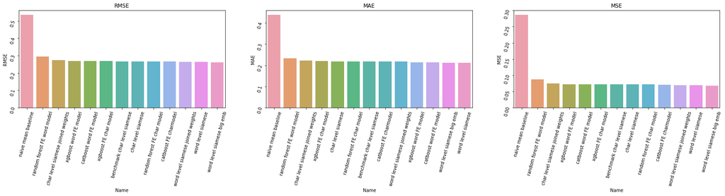

```python
import seaborn as sns

def plot_statistics_summary():
    summary = pd.read_csv('./model_results.csv', encoding='latin-1')

    fig, ax = plt.subplots(1, 3, figsize=(28, 4))
    for i, col in enumerate(['RMSE', 'MAE', 'MSE']):
        df = summary[['Name', col]].sort_values(by=[col], ascending=False)
        sns.barplot(x='Name', y=col, alpha=0.9, ax=ax[i], data=df)
        ax[i].tick_params(labelrotation=75)
        ax[i].set_title(col)

plot_statistics_summary()
```

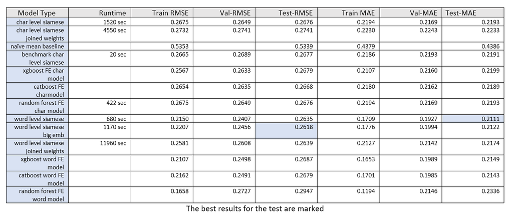

```python
display_image('summary_table.png')
```

## Suggestions for further improvement

We can suggest a few ways in order to improve our model and overcome the overfitting that occurs while training:

- **Classification instead of regression -** since the relevance values (Y) are discrete in the range [1, 3] we could view the problem as a classification problem.  
  Instead of trying to use regression to produce the relevance value associated with the search term and the description,  
  we could try to classify the simillarity between them to one of the unique relevance values in out dataset.
- **Increase the representation of word/character vectors -** we used the mean value of the word/charcter count as the size of the sentence representation vector in order to avoid exploding runtime.  
  By doing that we may have lost information regarding the rest of the sentence for sentences that are longer than the mean value.  
  We could represent all of the sentences as the maximum value or increase it to some value instead of the mean to avoid losing data.(down side is it will cause also for some sentences to have more zero padding at the end of each sentence, can cause the model to converge slower).
- **Use better/more suited tokenization and word processing methods -** we used a pretty simplistic sentence/word tokenization techniques (stemming, lowercasing etc.)  
  Going forawrd we could try and use tokenization techniques that take the context of the sentence into account in order to better determine simillarity.  
  We could also try and explore tokenization without using lowercasing or with using lemmenization instead of stemming. Another options is to keep the stop words in our corpus to better preserve context. Maybe we should keep some of the punctuation in the sentence to preserve some of the original meaning of tokenize by spaces and not by punctuation alltogether. It is also a possibility that the preprocessing of the sentence was too aggresive due to the stemming and stop words removal proccess and this will result in a lower quality embedding since we lose some connections - we could try different types of sentence preprocessing.
- **Increase Embedding dimensions -** We could try using an even larger word vector representation to preserve more sentence data con context in the embedding vectorized word representation.
- **Exploring better simillarity functions -** We tried using two different simillarity functions (Exponent manhatten distance and Cosine simillarity).  
  We could try and explore more simillarity metrics that may be better suited to our problem.
- **Networks architecture improvements suggestions -**
  - Add LSTM hidden nodes to better preserve history.
  - Add Dense/Conv layers.
  - Add more dropout to avoid overfitting to training data.
  - Try different activations/loss functions (if converted to classification task we could use categorical crossentropy instead of RMSE and softmax activation on last layer instead of sigmoid).

# Our Learning Process

In this assignment we learned how to use siamese networks in order to determine simillarity betweeen word/character sequences.  
We learned how to perform two forms of word/character tokenization (by using the keras Tokenizer class and the CountVectorizer class).  
We also learned how to perform text analysis, preprocessing(splitting, stemming and stop words removal) and using the word2vec models in order to create predefined embedding layers with vectorized representations for words in corpus.  
We used feature extraction on pretrained models and combined them with a few ML algorithms such as XGBoost, CatBoost and Random Forests.